# Prosocial Motivation Analysis

2025-12-09

# 1 Set up

```r
knitr::opts_chunk$set(echo = TRUE)

# Load packages
library(dplyr)
```

```r
library(stringr)
library(tidyr)
library(ggplot2)
library(psych)
library(DT)
library(tidyverse)
library(styler)
library(moments)
library(lme4)
library(lmerTest)
library(emmeans)
library(pbkrtest)
library(effectsize)
library(apaTables)
library(interactions)
library(visreg)
library(gtsummary)
library(sjPlot)
library(patchwork)
library(simr)
library(car)
# Clear work space
rm(list = ls())

# Set system language
Sys.setenv(LANG = "en")

# Read file
task_filename <- "../Cleaned data/Prosocial_motivation_cleaned_data.csv"
mot_clean <- read.csv(task_filename, header = TRUE)
```

## 1.1 Create Functions

Create functions to support other analysis.

linear_regression_results_table: Function to run a series of linear models and return a summary table

get_summary_with_CI: Creating a summary table of the variable’s Mean, SD, N, and CI

get_one_sample_results: Create a table with the t-test results of each variables against mu = 0

get_cont_descriptives: Summarize the continuous variables

```r
#---------------------------------
# Function to run a series of linear models and return a summary table
#---------------------------------
# Inputs:
# 1. predictors: character vector of predictor variable names
# 2. outcome: character vector of outcome variable names (1 or more)
# Output: a summary table of the key parameters of the models
linear_regression_results_table <- function(predictors, outcomes, data = mot_clean) {
  # Fixed controls variables across models
  controls <- c("age", "gender", "income")

  # Loop over all outcome × predictor combinations
  results_list <- lapply(outcomes, function(y) {
    lapply(predictors, function(var) {
      # Build formula: outcome ~ predictor + controls
      formula_str <- paste(y, "~", paste(c(var, controls), collapse = " + "))
      f <- as.formula(formula_str)

      # Fit model
      fit <- lm(f, data = data)

      # Parameters
      s   <- summary(fit)
      coefs <- coef(s)
      est  <- coefs[var, "Estimate"]
      se   <- coefs[var, "Std. Error"]
      tval <- coefs[var, "t value"]
      pval <- coefs[var, "Pr(>|t|)"]

      # Effect size: semi-partial R^2 (ΔR^2)
      fit_reduced <- update(fit, paste(". ~ . -", var))
      semi_partial_r2 <- s$r.squared -
        summary(fit_reduced)$r.squared

      n <- nrow(model.frame(fit))

      # Create a df with descriptions and model parameters
      data.frame(
        outcome   = y,
        predictor = var,
        estimate  = est,
        std_error = se,
        t_value   = tval,
        p_value   = pval,
        semi_partial_r2  = semi_partial_r2,
        r_squared = s$r.squared,
        adj_r2    = s$adj.r.squared,
        stringsAsFactors = FALSE
      )
    })
  })

  # Turn the outcomes × predictors parameters into one df
  results <- do.call(rbind, lapply(results_list, function(x)
    do.call(rbind, x)))

  # Round the other numeric columns to 2 digits
  num_cols <- c("estimate",
                "std_error",
                "t_value",
                "semi_partial_r2",
                "r_squared",
                "adj_r2")
  results[num_cols] <- lapply(results[num_cols], function(x)
    round(x, 2))

  # Return the results df
  return(results)
}

#---------------------------------
# Functions to create descriptive visualization dot plots
#---------------------------------
# ----- Prepare the data: get_summary_with_CI function -----
# Creating a summary table of the variable's Mean, SD, N, and CI
# Input: var_names (a list of names of the interested variables)
# Output: var_summary (a summary table of the variables' mean, sd, n, and CI)
get_summary_with_CI <- function(var_names) {
  # Reshape mot_clean to long format
  var_long <- mot_clean %>%
    # Select only the needed variables
    dplyr::select(all_of(var_names)) %>%
    # Transform into long format
    pivot_longer(cols = everything(),
                 names_to = "variable_name",
                 values_to = "rating")

  # Calculate Mean, SD, N, and CI
  var_summary <- Rmisc::summarySE(
    var_long,
    measurevar = "rating",
    groupvars = "variable_name",
    na.rm = TRUE
  )

  # Reorder variable_name based on the mean rating
  var_summary <- var_summary %>%
    mutate(variable_name = fct_reorder(variable_name, rating))

  # Return the summary table
  return(var_summary)
}

# ----- t-test results table -----
# Create a table with the t-test results of each variables against mu = 0
# Input: A vector of variable names
# Output: t-test results table
get_one_sample_results <- function(var_names) {
  # For each variable name, create a row of results
  one_sample_results <- map_df(var_names, function(var_name) {
    data_vec <- mot_clean[[var_name]]
    data_vec <- data_vec[!is.na(data_vec)]
    # Run One-Sample T-test against 0
    t_res <- t.test(data_vec, mu = 0)
    # Calculate Cohen's d for one-sample
    d_res <- effectsize::cohens_d(data_vec, mu = 0)
    # Return results row
    data.frame(
      Variable = var_name,
      Mean     = round(mean(data_vec), 2),
      t_stat   = round(t_res$statistic, 2),
      df       = t_res$parameter,
      p_value  = t_res$p.value,
      Cohens_d = round(d_res$Cohens_d, 2),
      CI_Lower = round(d_res$CI_low, 2),
      CI_Upper = round(d_res$CI_high, 2)
    )
  })
  # Arrange by Effect Size
  one_sample_results <- one_sample_results %>%
    mutate(p_adj = round(p.adjust(p_value, method = "bonferroni"), 3)) %>%
    arrange(desc(abs(Cohens_d)))

  return(one_sample_results)
}

#---------------------------------
# Create a function to summarize the continuous variables
#---------------------------------
# Input: A vector of variable names
# Output: Descrtiptive table
get_cont_descriptives <- function(num_vars) {
  # Create the summary table
  cont_descriptive <- t(sapply(num_vars, function(var_names) {
    x <- mot_clean[[var_names]]
    c(
      min       = min(x, na.rm = TRUE),
      max       = max(x, na.rm = TRUE),
      mean      = round(mean(x, na.rm = TRUE), digits = 2),
      sd        = round(sd(x, na.rm = TRUE), digits = 2),
      skewness  = round(skewness(x, na.rm = TRUE), digits = 2),
      kurtosis  = round(kurtosis(x, na.rm = TRUE), digits = 2)
    )
  }))

  # Reorder columns
  cont_descriptive <- as.data.frame(cont_descriptive)
  cont_descriptive$variable <- rownames(cont_descriptive)
  rownames(cont_descriptive) <- NULL
  cont_descriptive <- cont_descriptive[, c("variable", "mean", "sd", "min", "max", "skewness", "kurtosis")]

  # Round numeric columns
  cont_descriptive[, c("mean", "sd", "min", "max", "skewness", "kurtosis")] <-
    lapply(cont_descriptive[, c("mean", "sd", "min", "max", "skewness", "kurtosis")], function(x)
      round(as.numeric(x), 3))

  # Return the descrtiptive table
  return(cont_descriptive)
}
```

# 2 Demographic tables and key variables

## 2.1 Descriptive summary tables

```r
#---------------------------------
# Summarize the continuous variables
#---------------------------------
# Variables in the summary table
num_vars <- c(
  "age",
  "change_goal_initial",
  "change_goal_final",
  "prosociality",
  "TriPM_total",
  "AUC",
  "k_exponential"
)

# Create the summary table
cont_descriptive <- t(sapply(num_vars, function(var_names) {
  x <- mot_clean[[var_names]]
  c(
    mean      = mean(x, na.rm = TRUE),
    sd        = sd(x, na.rm = TRUE),
    min       = min(x, na.rm = TRUE),
    max       = max(x, na.rm = TRUE),
    skewness  = skewness(x, na.rm = TRUE),
    kurtosis  = kurtosis(x, na.rm = TRUE)
  )
}))

# Reorder columns
cont_descriptive <- as.data.frame(cont_descriptive)
cont_descriptive$variable <- rownames(cont_descriptive)
rownames(cont_descriptive) <- NULL
cont_descriptive <- cont_descriptive[, c("variable", "mean", "sd", "min", "max", "skewness", "kurtosis")]

# Round numeric columns
cont_descriptive[, c("mean", "sd", "min", "max", "skewness", "kurtosis")] <-
  lapply(cont_descriptive[, c("mean", "sd", "min", "max", "skewness", "kurtosis")], function(x)
    round(as.numeric(x), 2))

# Print the continuous variable summary
knitr::kable(cont_descriptive, caption = "Descriptives of Key Variables")
```

Descriptives of Key Variables

| variable | mean | sd | min | max | skewness | kurtosis |
| --- | --- | --- | --- | --- | --- | --- |
| age | 37.46 | 10.66 | 19.00 | 71.00 | 0.75 | 3.25 |
| change_goal_initial | 0.86 | 1.26 | -3.00 | 3.00 | -0.21 | 2.87 |
| change_goal_final | 1.44 | 1.15 | -2.00 | 3.00 | -0.80 | 3.51 |
| prosociality | 3.51 | 0.72 | 1.70 | 4.90 | -0.32 | 2.43 |
| TriPM_total | 49.16 | 17.11 | 14.00 | 106.00 | 0.62 | 3.55 |
| AUC | 0.23 | 0.21 | 0.00 | 1.00 | 1.12 | 3.81 |
| k_exponential | 0.03 | 0.02 | -0.01 | 0.09 | 0.06 | 1.92 |

```r
#---------------------------------
# Summarize the categorical demographics
#---------------------------------
# Make sure the variables are factors
factor_vars <- c(
  "feedback_first",
  "gender",
  "race",
  "education",
  "employment",
  "religion",
  "income_categorical"
)

mot_clean[factor_vars] <- lapply(mot_clean[factor_vars], as.factor)

# Create summary table
summary(mot_clean[, c("gender",
                      "education",
                      "religion",
                      "race",
                      "employment",
                      "income_categorical"
                      )])
```

```
##        gender   education    religion               race       employment
##  Female   :98   1: 1      1      :52   American Indian:  1   1      :113
##  Male     :99   2:30      2      :44   Asian          : 21   2      : 30
##  Nonbinary: 3   3:43      10     :44   Black          : 20   11     : 14
##                 4:18      9      :27   Hispanic       : 12   13     : 12
##                 5:75      12     :19   multiple       : 22   3      :  8
##                 6:29      11     : 8   Native Hawaiian:  1   (Other): 18
##                 7: 4      (Other): 6   White          :123   NA's   :  5
##          income_categorical
##  $40,000 - 59,999 :48
##  $90,000 - 179,999:48
##  $60,000 - 89,999 :38
##  $25,000 - 39,999 :31
##  $15,000 - 24,999 :12
##  Over $180,000    :12
##  (Other)          :11
```

```r
# Create summary table
mot_clean %>%
  dplyr::select(all_of(factor_vars)) %>%
  tbl_summary(
    statistic = list(all_categorical() ~ "{n} ({p}%)"),
    digits = list(all_categorical() ~ c(0, 1))
  )
```

| **Characteristic** | **N = 200**<sup>1</sup> |
| --- | --- |
| feedback_first |  |
| 0 | 98 (49.0%) |
| 1 | 102 (51.0%) |
| gender |  |
| Female | 98 (49.0%) |
| Male | 99 (49.5%) |
| Nonbinary | 3 (1.5%) |
| race |  |
| American Indian | 1 (0.5%) |
| Asian | 21 (10.5%) |
| Black | 20 (10.0%) |
| Hispanic | 12 (6.0%) |
| multiple | 22 (11.0%) |
| Native Hawaiian | 1 (0.5%) |
| White | 123 (61.5%) |
| education |  |
| 1 | 1 (0.5%) |
| 2 | 30 (15.0%) |
| 3 | 43 (21.5%) |
| 4 | 18 (9.0%) |
| 5 | 75 (37.5%) |
| 6 | 29 (14.5%) |
| 7 | 4 (2.0%) |
| employment |  |
| 1 | 113 (57.9%) |
| 2 | 30 (15.4%) |
| 3 | 8 (4.1%) |
| 4 | 4 (2.1%) |
| 5 | 3 (1.5%) |
| 6 | 1 (0.5%) |
| 9 | 4 (2.1%) |
| 10 | 5 (2.6%) |
| 11 | 14 (7.2%) |
| 12 | 1 (0.5%) |
| 13 | 12 (6.2%) |
| Unknown | 5 |
| religion |  |
| 1 | 52 (26.0%) |
| 2 | 44 (22.0%) |
| 4 | 1 (0.5%) |
| 5 | 2 (1.0%) |
| 6 | 1 (0.5%) |
| 7 | 2 (1.0%) |
| 9 | 27 (13.5%) |
| 10 | 44 (22.0%) |
| 11 | 8 (4.0%) |
| 12 | 19 (9.5%) |
| income_categorical |  |
| $10,000 - 14,999 | 4 (2.0%) |
| $15,000 - 24,999 | 12 (6.0%) |
| $25,000 - 39,999 | 31 (15.5%) |
| $40,000 - 59,999 | 48 (24.0%) |
| $5,000 - 9,999 | 1 (0.5%) |
| $60,000 - 89,999 | 38 (19.0%) |
| $90,000 - 179,999 | 48 (24.0%) |
| Over $180,000 | 12 (6.0%) |
| Under $5,000 | 6 (3.0%) |

<sup>1</sup> n (%)

# 3 Bivariate analysis

## 3.1 Key variables

Descriptive and correlation table of key variables (prosociality/honesty-humility, TriPM, SDT, change goals, personality domains, age).

Correlation between prosocial-related variables (prosociality/honesty-humility and SDT parameters) -> confirm the link by examining the relationship between the honesty-humility trait and social discounting parameters.

```r
#---------------------------------
# Bivariate analysis - key vars
#---------------------------------
# Variables of interest
var_cols <- c(
  "change_goal_initial",
  "change_goal_final",
  "prosociality",
  "TriPM_total",
  "AUC",
  "k_exponential",
  "age"
)

# ----- Creating correlation table -----
apa.cor.table(mot_clean[, var_cols], table.number = 2, filename = "../Figures/Correlations.doc")
```

```
##
##
## Table 2
##
## Means, standard deviations, and correlations with confidence intervals
##
##
##   Variable               M     SD    1            2            3
##   1. change_goal_initial 0.86  1.26
##
##   2. change_goal_final   1.44  1.15  .34**
##                                      [.21, .46]
##
##   3. prosociality        3.51  0.72  .19**        -.37**
##                                      [.05, .32]   [-.48, -.24]
##
##   4. TriPM_total         49.16 17.11 -.16*        .01          -.33**
##                                      [-.29, -.02] [-.13, .14]  [-.45, -.20]
##
##   5. AUC                 0.23  0.21  .16*         -.06         .16*
##                                      [.02, .29]   [-.19, .08]  [.02, .29]
##
##   6. k_exponential       0.03  0.02  -.08         .12          -.17*
##                                      [-.22, .06]  [-.02, .26]  [-.30, -.03]
##
##   7. age                 37.46 10.66 -.09         -.25**       .30**
##                                      [-.22, .05]  [-.38, -.12] [.16, .42]
##
##   4           5            6
##
##
##
##
##
##
##
##
##
##
##
##   .08
##   [-.06, .22]
##
##   -.01        -.82**
##   [-.14, .13] [-.86, -.77]
##
##   -.05        -.03         .05
##   [-.19, .09] [-.16, .11]  [-.08, .19]
##
##
## Note. M and SD are used to represent mean and standard deviation, respectively.
## Values in square brackets indicate the 95% confidence interval.
## The confidence interval is a plausible range of population correlations
## that could have caused the sample correlation (Cumming, 2014).
##  * indicates p < .05. ** indicates p < .01.
##
```

```r
# ----- Calculate correlation between vars of interest -----
# Correlation between Honesty-humility and AUC
cor.test(mot_clean$prosociality, mot_clean$AUC, method = "pearson")
```

```
##
##  Pearson's product-moment correlation
##
## data:  mot_clean$prosociality and mot_clean$AUC
## t = 2.3137, df = 198, p-value = 0.02171
## alternative hypothesis: true correlation is not equal to 0
## 95 percent confidence interval:
##  0.02404883 0.29436324
## sample estimates:
##       cor
## 0.1622485
```

```r
# Correlation between Honesty-humility and k_exponential
cor.test(mot_clean$prosociality, mot_clean$k_exponential, method = "pearson")
```

```
##
##  Pearson's product-moment correlation
##
## data:  mot_clean$prosociality and mot_clean$k_exponential
## t = -2.4197, df = 198, p-value = 0.01644
## alternative hypothesis: true correlation is not equal to 0
## 95 percent confidence interval:
##  -0.30113499 -0.03147361
## sample estimates:
##        cor
## -0.1694746
```

```r
# Correlation between Honesty-humility and TriPM_total
cor.test(mot_clean$prosociality, mot_clean$TriPM_total, method = "pearson")
```

```
##
##  Pearson's product-moment correlation
##
## data:  mot_clean$prosociality and mot_clean$TriPM_total
## t = -4.9294, df = 198, p-value = 1.74e-06
## alternative hypothesis: true correlation is not equal to 0
## 95 percent confidence interval:
##  -0.4487746 -0.2011027
## sample estimates:
##        cor
## -0.3306191
```

```r
# Correlation between Honesty-humility and TriPM_meanness
cor.test(mot_clean$prosociality, mot_clean$TriPM_meanness, method = "pearson")
```

```
##
##  Pearson's product-moment correlation
##
## data:  mot_clean$prosociality and mot_clean$TriPM_meanness
## t = -5.7529, df = 198, p-value = 3.291e-08
## alternative hypothesis: true correlation is not equal to 0
## 95 percent confidence interval:
##  -0.4913758 -0.2529754
## sample estimates:
##        cor
## -0.3784342
```

```r
# Correlation between Honesty-humility and TriPM_boldness
cor.test(mot_clean$prosociality, mot_clean$TriPM_boldness, method = "pearson")
```

```
##
##  Pearson's product-moment correlation
##
## data:  mot_clean$prosociality and mot_clean$TriPM_boldness
## t = 0.51553, df = 198, p-value = 0.6068
## alternative hypothesis: true correlation is not equal to 0
## 95 percent confidence interval:
##  -0.1026500  0.1744673
## sample estimates:
##        cor
## 0.03661248
```

```r
# Correlation between Honesty-humility and TriPM_disinhibition
cor.test(mot_clean$prosociality,
         mot_clean$TriPM_disinhibition,
         method = "pearson")
```

```
##
##  Pearson's product-moment correlation
##
## data:  mot_clean$prosociality and mot_clean$TriPM_disinhibition
## t = -5.0903, df = 198, p-value = 8.289e-07
## alternative hypothesis: true correlation is not equal to 0
## 95 percent confidence interval:
##  -0.4573332 -0.2114136
## sample estimates:
##        cor
## -0.3401767
```

# 4 Goal One: Prosociality change goals

## 4.1 Initial prosociality change goal

The following block calculated the percentage of participants who wanted to be more, less prosocial, or stay the same. It also tests the extent to which individuals’ prosociality level is linked to their prosociality change goals.

```r
#---------------------------------
# Participants initial change goals >0, <0, or =0
#---------------------------------
# ----- initial change goal -----
# % wanting to be less prosocial
sum(mot_clean$change_goal_initial < 0) / nrow(mot_clean)
```

```
## [1] 0.115
```

```r
# % wanting to be more prosocial
sum(mot_clean$change_goal_initial > 0) / nrow(mot_clean)
```

```
## [1] 0.615
```

```r
# % wanting to stay the same
sum(mot_clean$change_goal_initial == 0) / nrow(mot_clean)
```

```
## [1] 0.27
```

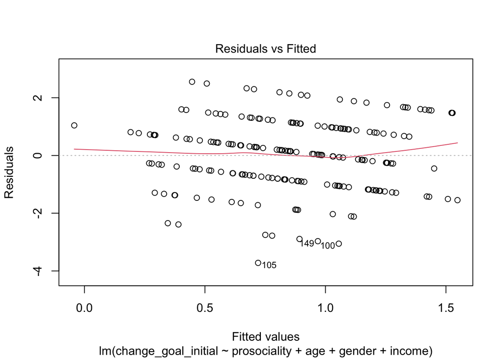

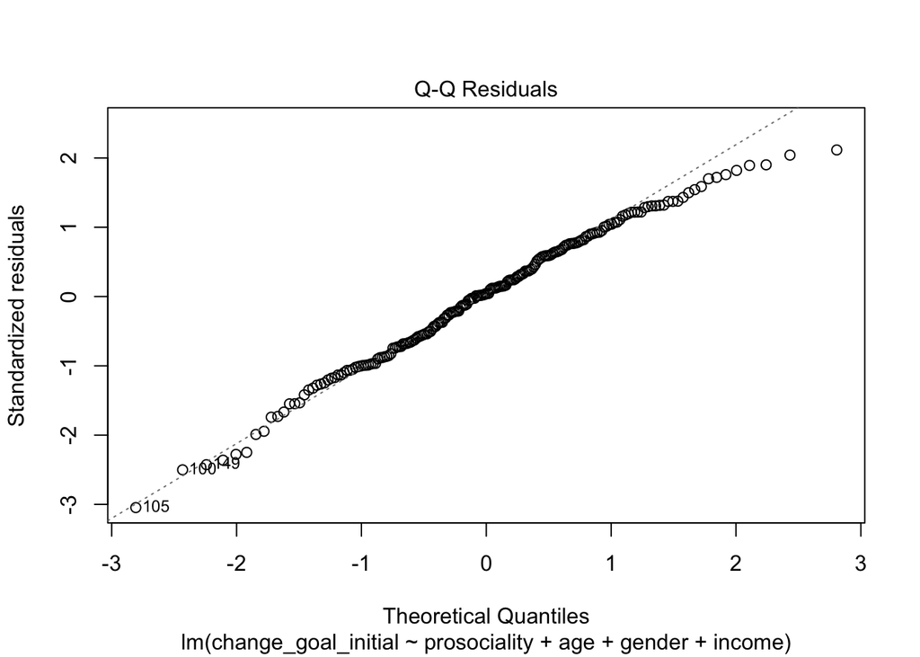

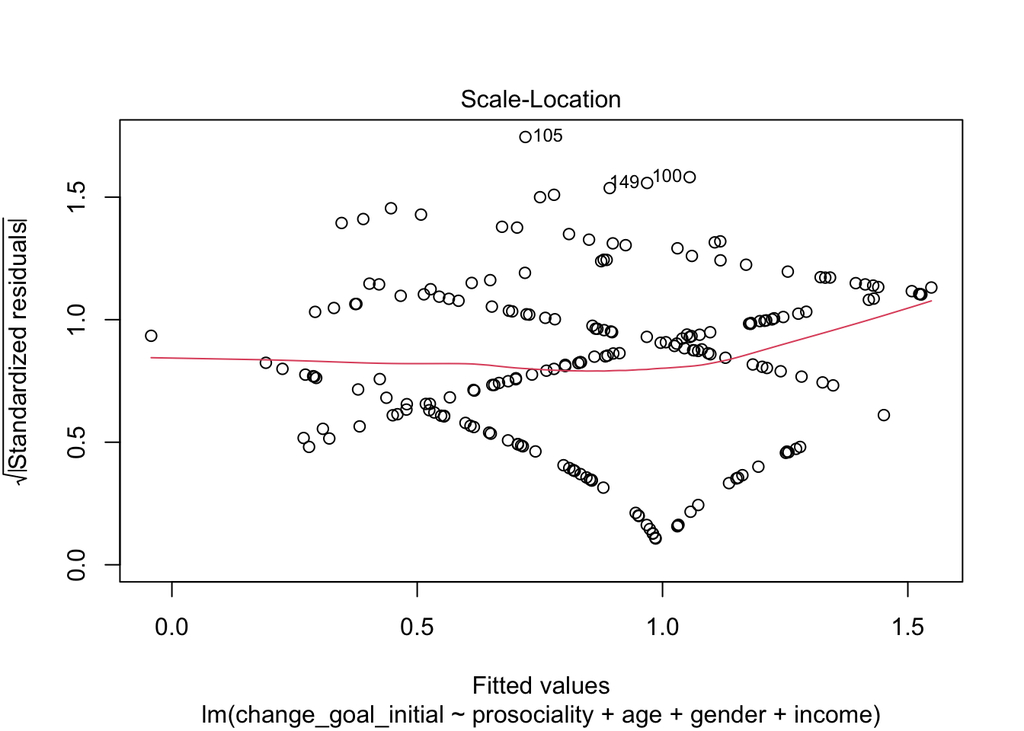

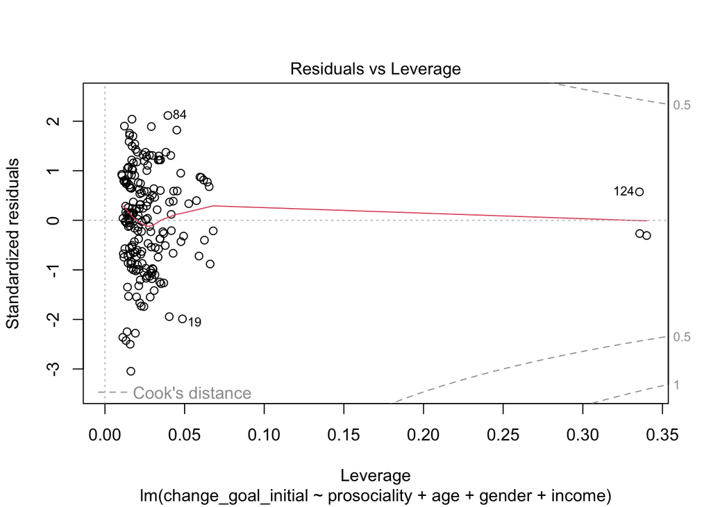

```r
#---------------------------------
# Initial change goal vs prosociality
#---------------------------------
# With control var only
control_model <- lm(change_goal_initial ~ age + gender + income, data = mot_clean)

# With prosocial predictor
prosocial_model <- lm(change_goal_initial ~ prosociality + age + gender + income, data = mot_clean)

# Check assumptions
plot(prosocial_model)
```

```r
# Summarize prosocial model
summary(prosocial_model)
```

```
##
## Call:
## lm(formula = change_goal_initial ~ prosociality + age + gender +
##     income, data = mot_clean)
##
## Residuals:
##     Min      1Q  Median      3Q     Max
## -3.7205 -0.8406  0.0488  0.9219  2.5534
##
## Coefficients:
##                  Estimate Std. Error t value Pr(>|t|)
## (Intercept)     -0.029810   0.593053  -0.050 0.959963
## prosociality     0.432409   0.128020   3.378 0.000883 ***
## age             -0.020319   0.008667  -2.345 0.020062 *
## genderMale      -0.094957   0.177076  -0.536 0.592401
## genderNonbinary -0.828134   0.728597  -1.137 0.257102
## income           0.031014   0.050744   0.611 0.541802
## ---
## Signif. codes:  0 '***' 0.001 '**' 0.01 '*' 0.05 '.' 0.1 ' ' 1
##
## Residual standard error: 1.231 on 194 degrees of freedom
## Multiple R-squared:  0.06713,    Adjusted R-squared:  0.04309
## F-statistic: 2.792 on 5 and 194 DF,  p-value: 0.01847
```

## 4.2 Prosociality construal change goals

The following block tests whether the prosocial construals we provided motivated people.

```r
# List of the prosocial construals motivation variables
traits <- c(
  "honest_change_goal",
  "humble_change_goal",
  "selfless_change_goal",
  "caring_change_goal",
  "moral_change_goal",
  "altruistic_change_goal",
  "helpful_change_goal",
  "generous_change_goal",
  "empathetic_change_goal",
  "compassionate_change_goal",
  "kind_change_goal",
  "considerate_change_goal",
  "cooperative_change_goal"
)

#---------------------------------
# Create the summary tables
#---------------------------------
# Create table using the get_cont_descriptives function
traits_descriptives <- get_cont_descriptives(traits)
# Rank from highest mean to lowest
traits_descriptives <- traits_descriptives %>%
  arrange(desc(mean))
# Print the summary table
knitr::kable(traits_descriptives, caption = "Descriptives of the Prosocial Construal Change Goals")
```

Descriptives of the Prosocial Construal Change Goals

| variable | mean | sd | min | max | skewness | kurtosis |
| --- | --- | --- | --- | --- | --- | --- |
| helpful_change_goal | 1.11 | 1.25 | -2 | 3 | -0.16 | 2.29 |
| kind_change_goal | 1.00 | 1.14 | -2 | 3 | 0.30 | 2.37 |
| considerate_change_goal | 1.00 | 1.17 | -2 | 3 | 0.16 | 2.24 |
| generous_change_goal | 0.98 | 1.27 | -2 | 3 | -0.06 | 2.41 |
| caring_change_goal | 0.93 | 1.16 | -2 | 3 | 0.16 | 2.32 |
| cooperative_change_goal | 0.92 | 1.19 | -2 | 3 | 0.20 | 2.35 |
| compassionate_change_goal | 0.85 | 1.17 | -2 | 3 | 0.33 | 2.55 |
| honest_change_goal | 0.83 | 1.09 | -2 | 3 | 0.36 | 2.67 |
| altruistic_change_goal | 0.81 | 1.04 | -2 | 3 | 0.49 | 2.95 |
| moral_change_goal | 0.79 | 1.12 | -2 | 3 | 0.42 | 2.83 |
| selfless_change_goal | 0.76 | 1.29 | -3 | 3 | -0.13 | 2.67 |
| empathetic_change_goal | 0.76 | 1.26 | -3 | 3 | -0.03 | 2.93 |
| humble_change_goal | 0.66 | 1.20 | -3 | 3 | 0.40 | 2.81 |

```r
# Create table using the get_one_sample_results function
traits_t_test <- get_one_sample_results(traits)
# Print the summary table
knitr::kable(traits_t_test, caption = "One Sample T-Test Results of the Prosocial Construal Change Goals")
```

One Sample T-Test Results of the Prosocial Construal Change Goals

|  | Variable | Mean | t_stat | df | p_value | Cohens_d | CI_Lower | CI_Upper | p_adj |
| --- | --- | --- | --- | --- | --- | --- | --- | --- | --- |
| t…1 | helpful_change_goal | 1.11 | 12.59 | 199 | 0 | 0.89 | 0.73 | 1.05 | 0 |
| t…2 | kind_change_goal | 1.00 | 12.37 | 199 | 0 | 0.87 | 0.71 | 1.04 | 0 |
| t…3 | considerate_change_goal | 1.00 | 12.06 | 199 | 0 | 0.85 | 0.69 | 1.01 | 0 |
| t…4 | caring_change_goal | 0.93 | 11.31 | 199 | 0 | 0.80 | 0.64 | 0.96 | 0 |
| t…5 | altruistic_change_goal | 0.81 | 10.98 | 199 | 0 | 0.78 | 0.62 | 0.93 | 0 |
| t…6 | generous_change_goal | 0.98 | 10.93 | 199 | 0 | 0.77 | 0.61 | 0.93 | 0 |
| t…7 | cooperative_change_goal | 0.92 | 10.84 | 199 | 0 | 0.77 | 0.61 | 0.92 | 0 |
| t…8 | honest_change_goal | 0.83 | 10.73 | 199 | 0 | 0.76 | 0.60 | 0.92 | 0 |
| t…9 | compassionate_change_goal | 0.85 | 10.25 | 199 | 0 | 0.73 | 0.57 | 0.88 | 0 |
| t…10 | moral_change_goal | 0.79 | 9.94 | 199 | 0 | 0.70 | 0.55 | 0.86 | 0 |
| t…11 | empathetic_change_goal | 0.76 | 8.56 | 199 | 0 | 0.61 | 0.45 | 0.76 | 0 |
| t…12 | selfless_change_goal | 0.76 | 8.34 | 199 | 0 | 0.59 | 0.44 | 0.74 | 0 |
| t…13 | humble_change_goal | 0.66 | 7.77 | 199 | 0 | 0.55 | 0.40 | 0.70 | 0 |

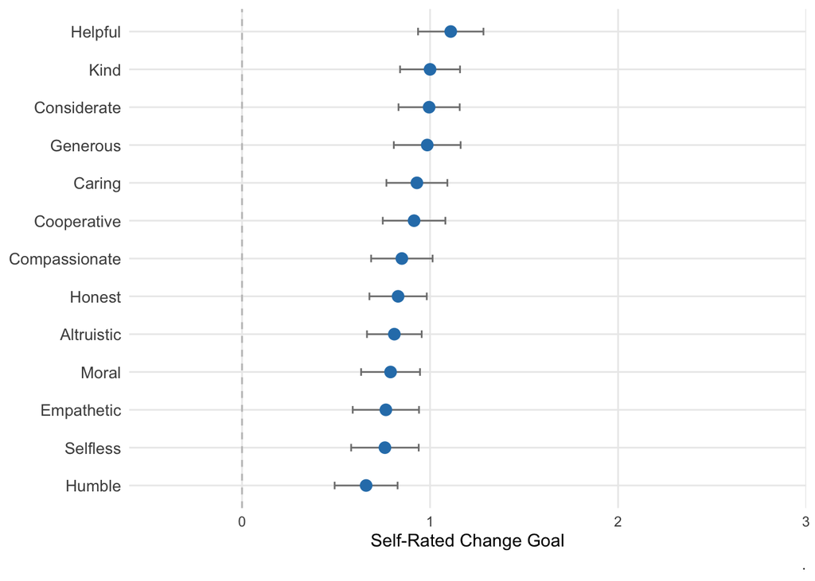

```r
#---------------------------------
# Create the dot graph with CI
#---------------------------------
# Creating a summary table of the prosocial construal change goals' Mean, SD, N, and CI using the get_summary_with_CI function
traits_summary_with_CI <- get_summary_with_CI(traits)

# Drafting a dot plot of mean change goal ratings with CI
traits_dot_plot <- ggplot(traits_summary_with_CI, aes(x = variable_name, y = rating)) +
  # Draw the error bars
  geom_errorbar(aes(ymin = rating - ci, ymax = rating + ci),
                width = 0.2,
                color = "gray50") +
  # Draw the mean points
  geom_point(size = 3, color = "#2c7fb8") +

  # Set range
  # Remane the lables
  scale_y_continuous(breaks = c(0, 1, 2, 3), expand = expansion(mult = c(0.2, 0))) +

  geom_hline(yintercept = 0,
             linetype = "dashed",
             color = "gray75") +

  # Rename variables
  scale_x_discrete(
    labels = c(
      "honest_change_goal" = "Honest",
      "humble_change_goal" = "Humble",
      "selfless_change_goal" = "Selfless",
      "caring_change_goal" = "Caring",
      "moral_change_goal" = "Moral",
      "altruistic_change_goal" = "Altruistic",
      "helpful_change_goal" = "Helpful",
      "generous_change_goal" = "Generous",
      "empathetic_change_goal" = "Empathetic",
      "compassionate_change_goal" = "Compassionate",
      "kind_change_goal" = "Kind",
      "considerate_change_goal" = "Considerate",
      "cooperative_change_goal" = "Cooperative"
    )
  ) +

  # Flip coordinates for easier reading
  coord_flip(ylim = c(0, 3)) +
  # Formatting for better visualization
  theme_minimal() +
  theme(
    panel.grid.minor = element_blank(),
    axis.title.y = element_blank(),
    axis.text.y = element_text(size = 10),
    plot.title = element_text(face = "bold")
  ) +
  # Add titles and axis labels
  labs(y = "Self-Rated Change Goal", caption = ".")

traits_dot_plot
```

```r
ggsave(
  filename = "../Figures/Figure 1_Mean Ratings of the Motivation to Change Prosocial Traits.png",
  plot = traits_dot_plot,
  width = 6,
  height = 4,
  dpi = 300
)
```

# 5 Goal Two: Conditions’ effects on change goals

Second, we examine whether psychoeducation or feedback on their own prosociality is effective in inspiring prosociality improvements among individuals with different characteristics.

```r
#---------------------------------
# Data prep
#---------------------------------
# Select variables for analysis
MEM_var <- mot_clean %>%
  select(
    # id, condition order, & controls
    participant_id,
    feedback_first,
    age,
    gender,
    income,

    # prosociality & psychopathy
    prosociality,
    TriPM_total,

    # change goal variables
    change_goal_initial,
    change_goal_final,
    change_goal_pre_feedback,
    change_goal_post_feedback,
    change_goal_pre_psychoed,
    change_goal_post_psychoed
  )
```

## 5.1 All conditions

Compare the change goals before and after all conditions (psychoed + feedback).

### 5.1.1 Models

```r
#---------------------------------
# Prep
#---------------------------------
# Transform MEM_var from long to wide
mot_all <- MEM_var %>%
  pivot_longer(
    cols = c(change_goal_initial, change_goal_final),
    names_to = "time_all_conditions",
    values_to = "change_goal_all_condition"
  ) %>%
  mutate(
    time_all_conditions = dplyr::recode(
      time_all_conditions,
      change_goal_initial = "Initial",
      change_goal_final   = "Final"
    )
  )

# Factor time and reorder
mot_all$time_all_conditions <- factor(mot_all$time_all_conditions, levels = c("Initial", "Final"))

#---------------------------------
# Models
#---------------------------------
# ----- Standardize -----
mot_all_z <- mot_all

# z-score outcome + continuous predictors
mot_all_z$change_z        <- as.numeric(scale(mot_all_z$change_goal_all_condition))
mot_all_z$prosociality_z  <- as.numeric(scale(mot_all_z$prosociality))
mot_all_z$age_z           <- as.numeric(scale(mot_all_z$age))
mot_all_z$income_z        <- as.numeric(scale(mot_all_z$income))

# ----- Baseline models -----
model_empty_z <- lmer(change_z ~ 1 +
                        (1 | participant_id), data = mot_all_z)
summary(model_empty_z)
```

```
## Linear mixed model fit by REML. t-tests use Satterthwaite's method [
## lmerModLmerTest]
## Formula: change_z ~ 1 + (1 | participant_id)
##    Data: mot_all_z
##
## REML criterion at convergence: 1123.3
##
## Scaled residuals:
##     Min      1Q  Median      3Q     Max
## -3.2651 -0.6278  0.0172  0.6623  1.8089
##
## Random effects:
##  Groups         Name        Variance Std.Dev.
##  participant_id (Intercept) 0.2694   0.5190
##  Residual                   0.7313   0.8552
## Number of obs: 400, groups:  participant_id, 200
##
## Fixed effects:
##               Estimate Std. Error         df t value Pr(>|t|)
## (Intercept) -8.941e-17  5.635e-02  1.990e+02       0        1
```

```r
model_control_z <- lmer(change_z ~ age_z + gender + income_z +
                          (1 | participant_id), data = mot_all_z)
summary(model_control_z)
```

```
## Linear mixed model fit by REML. t-tests use Satterthwaite's method [
## lmerModLmerTest]
## Formula: change_z ~ age_z + gender + income_z + (1 | participant_id)
##    Data: mot_all_z
##
## REML criterion at convergence: 1122.6
##
## Scaled residuals:
##     Min      1Q  Median      3Q     Max
## -3.3505 -0.5310  0.0797  0.6019  1.8914
##
## Random effects:
##  Groups         Name        Variance Std.Dev.
##  participant_id (Intercept) 0.2480   0.4980
##  Residual                   0.7313   0.8552
## Number of obs: 400, groups:  participant_id, 200
##
## Fixed effects:
##                   Estimate Std. Error         df t value Pr(>|t|)
## (Intercept)       0.026390   0.079265 195.000000   0.333  0.73954
## age_z            -0.172437   0.055868 195.000000  -3.086  0.00232 **
## genderMale       -0.032129   0.111886 195.000000  -0.287  0.77430
## genderNonbinary  -0.699071   0.462457 195.000000  -1.512  0.13224
## income_z          0.006464   0.055536 195.000000   0.116  0.90746
## ---
## Signif. codes:  0 '***' 0.001 '**' 0.01 '*' 0.05 '.' 0.1 ' ' 1
##
## Correlation of Fixed Effects:
##             (Intr) age_z  gndrMl gndrNn
## age_z       -0.055
## genderMale  -0.710  0.065
## gendrNnbnry -0.178  0.109  0.129
## income_z     0.020  0.001 -0.022 -0.049
```

```r
model_x_interaction_z <- lmer(
  change_z ~ time_all_conditions + prosociality_z +
    age_z + gender + income_z +
    (1 | participant_id),
  data = mot_all_z
)
summary(model_x_interaction_z)
```

```
## Linear mixed model fit by REML. t-tests use Satterthwaite's method [
## lmerModLmerTest]
## Formula: change_z ~ time_all_conditions + prosociality_z + age_z + gender +
##     income_z + (1 | participant_id)
##    Data: mot_all_z
##
## REML criterion at convergence: 1097.5
##
## Scaled residuals:
##     Min      1Q  Median      3Q     Max
## -3.1783 -0.4579  0.0358  0.5597  2.2719
##
## Random effects:
##  Groups         Name        Variance Std.Dev.
##  participant_id (Intercept) 0.3032   0.5506
##  Residual                   0.6263   0.7914
## Number of obs: 400, groups:  participant_id, 200
##
## Fixed effects:
##                            Estimate Std. Error         df t value Pr(>|t|)
## (Intercept)               -0.208882   0.089018 284.484793  -2.347  0.01964 *
## time_all_conditionsFinal   0.465154   0.079137 199.000000   5.878 1.73e-08 ***
## prosociality_z            -0.022865   0.058863 194.000000  -0.388  0.69811
## age_z                     -0.165408   0.058841 194.000000  -2.811  0.00544 **
## genderMale                -0.027049   0.112890 194.000000  -0.240  0.81089
## genderNonbinary           -0.687052   0.464499 194.000000  -1.479  0.14073
## income_z                   0.004534   0.055878 194.000000   0.081  0.93541
## ---
## Signif. codes:  0 '***' 0.001 '**' 0.01 '*' 0.05 '.' 0.1 ' ' 1
##
## Correlation of Fixed Effects:
##             (Intr) tm_l_F prscl_ age_z  gndrMl gndrNn
## tm_ll_cndtF -0.445
## prosoclty_z  0.078  0.000
## age_z       -0.070  0.000 -0.307
## genderMale  -0.638  0.000 -0.116  0.097
## gendrNnbnry -0.163  0.000 -0.067  0.124  0.136
## income_z     0.025  0.000  0.089 -0.026 -0.032 -0.054
```

```r
# ----- Interaction Model - standardized -----
# Time x prosocial model
model_all_z <- lmer(
  change_z ~ time_all_conditions * prosociality_z + age_z + gender + income_z + (1 |
                                                                                   participant_id),
  data = mot_all_z
)
summary(model_all_z)
```

```
## Linear mixed model fit by REML. t-tests use Satterthwaite's method [
## lmerModLmerTest]
## Formula: change_z ~ time_all_conditions * prosociality_z + age_z + gender +
##     income_z + (1 | participant_id)
##    Data: mot_all_z
##
## REML criterion at convergence: 1049.5
##
## Scaled residuals:
##      Min       1Q   Median       3Q      Max
## -3.15649 -0.45648  0.04069  0.53386  2.72557
##
## Random effects:
##  Groups         Name        Variance Std.Dev.
##  participant_id (Intercept) 0.3734   0.6111
##  Residual                   0.4858   0.6970
## Number of obs: 400, groups:  participant_id, 200
##
## Fixed effects:
##                                           Estimate Std. Error         df
## (Intercept)                              -0.208882   0.087023 265.684665
## time_all_conditionsFinal                  0.465154   0.069697 198.000002
## prosociality_z                            0.244141   0.068427 316.051710
## age_z                                    -0.165408   0.058841 193.999997
## genderMale                               -0.027049   0.112890 193.999997
## genderNonbinary                          -0.687052   0.464499 193.999997
## income_z                                  0.004534   0.055878 193.999997
## time_all_conditionsFinal:prosociality_z  -0.534013   0.069784 198.000002
##                                         t value Pr(>|t|)
## (Intercept)                              -2.400 0.017069 *
## time_all_conditionsFinal                  6.674 2.44e-10 ***
## prosociality_z                            3.568 0.000416 ***
## age_z                                    -2.811 0.005444 **
## genderMale                               -0.240 0.810891
## genderNonbinary                          -1.479 0.140729
## income_z                                  0.081 0.935410
## time_all_conditionsFinal:prosociality_z  -7.652 8.46e-13 ***
## ---
## Signif. codes:  0 '***' 0.001 '**' 0.01 '*' 0.05 '.' 0.1 ' ' 1
##
## Correlation of Fixed Effects:
##             (Intr) tm_l_F prscl_ age_z  gndrMl gndrNn incm_z
## tm_ll_cndtF -0.400
## prosoclty_z  0.069  0.000
## age_z       -0.072  0.000 -0.265
## genderMale  -0.653  0.000 -0.100  0.097
## gendrNnbnry -0.167  0.000 -0.057  0.124  0.136
## income_z     0.025  0.000  0.076 -0.026 -0.032 -0.054
## tm_ll_cnF:_  0.000  0.000 -0.510  0.000  0.000  0.000  0.000
```

```r
tab_model(
  model_all_z,
  show.se = TRUE,
  show.stat = TRUE,
  show.ci = FALSE,
  p.style = "numeric",
  show.aic = FALSE,
  show.icc = FALSE,
  string.est = "Estimate",
  string.se = "SE",
  string.stat = "t",
  string.p = "p"
)
```

|  | change_z |  |  |  |
| --- | --- | --- | --- | --- |
| Predictors | Estimate | SE | t | p |
| (Intercept) | -0.21 | 0.09 | -2.40 | **0.017** |
| time all conditions [Final] | 0.47 | 0.07 | 6.67 | **<0.001** |
| prosociality z | 0.24 | 0.07 | 3.57 | **<0.001** |
| age z | -0.17 | 0.06 | -2.81 | **0.005** |
| gender [Male] | -0.03 | 0.11 | -0.24 | 0.811 |
| gender [Nonbinary] | -0.69 | 0.46 | -1.48 | 0.140 |
| income z | 0.00 | 0.06 | 0.08 | 0.935 |
| time all conditions [Final] × prosociality z | -0.53 | 0.07 | -7.65 | **<0.001** |
| Random Effects |  |  |  |  |
| σ<sup>2</sup> | 0.49 |  |  |  |
| τ<sub>00</sub> <sub>participant_id</sub> | 0.37 |  |  |  |
| N <sub>participant_id</sub> | 200 |  |  |  |
| Observations | 400 |  |  |  |
| Marginal R<sup>2</sup> / Conditional R<sup>2</sup> | 0.157 / 0.523 |  |  |  |

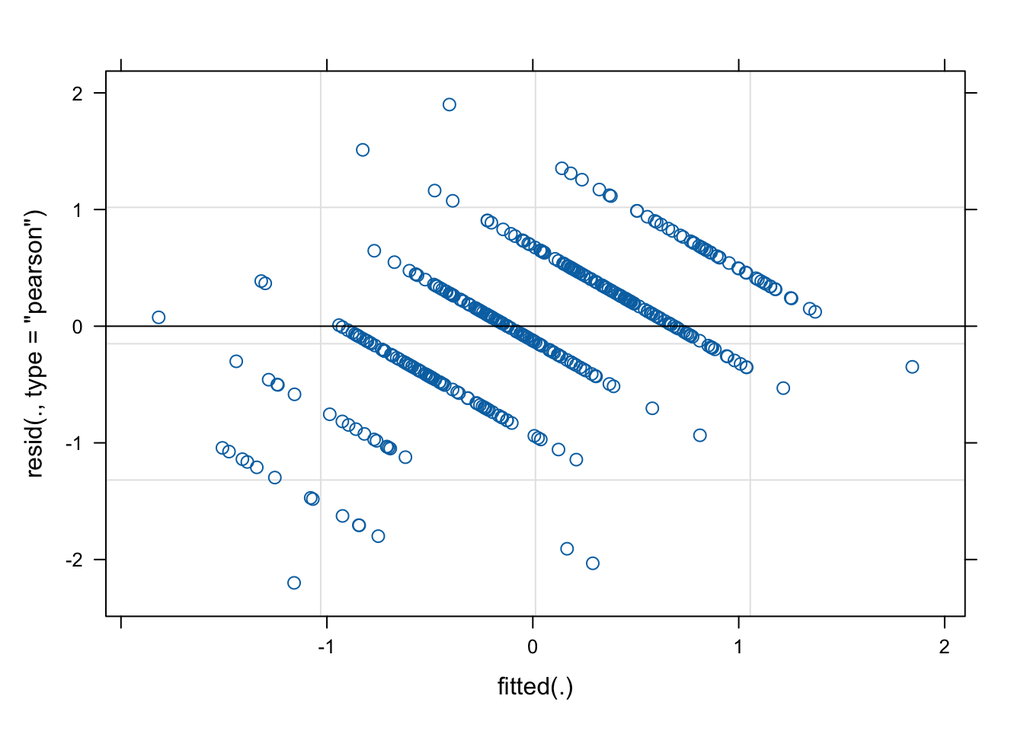

```r
# Check assumptions
plot(model_all_z)
```

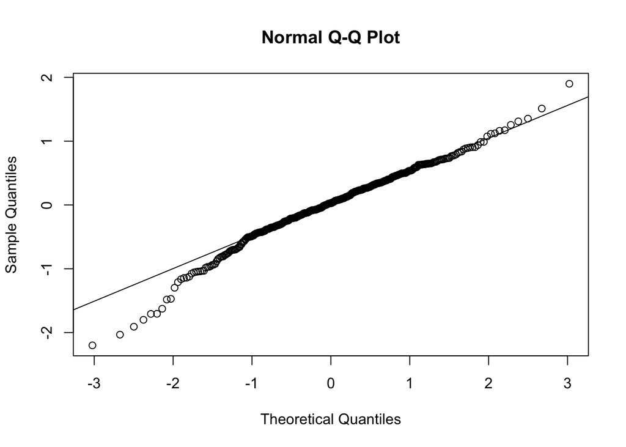

```r
qqnorm(resid(model_all_z))
qqline(resid(model_all_z))
```

```r
# ----- Interaction Model - non-standardized-----
# Time x prosocial model
model_all <- lmer(
  change_goal_all_condition ~ time_all_conditions * prosociality +
    age + gender + income +
    (1 | participant_id),
  data = mot_all
)

summary(model_all)
```

```
## Linear mixed model fit by REML. t-tests use Satterthwaite's method [
## lmerModLmerTest]
## Formula: change_goal_all_condition ~ time_all_conditions * prosociality +
##     age + gender + income + (1 | participant_id)
##    Data: mot_all
##
## REML criterion at convergence: 1220.2
##
## Scaled residuals:
##      Min       1Q   Median       3Q      Max
## -3.15649 -0.45648  0.04069  0.53386  2.72557
##
## Random effects:
##  Groups         Name        Variance Std.Dev.
##  participant_id (Intercept) 0.5706   0.7554
##  Residual                   0.7423   0.8616
## Number of obs: 400, groups:  participant_id, 200
##
## Fixed effects:
##                                         Estimate Std. Error         df t value
## (Intercept)                             0.123327   0.514202 272.423798   0.240
## time_all_conditionsFinal                3.789473   0.428807 198.000001   8.837
## prosociality                            0.418451   0.117283 316.051714   3.568
## age                                    -0.019200   0.006830 193.999999  -2.811
## genderMale                             -0.033436   0.139549 193.999999  -0.240
## genderNonbinary                        -0.849298   0.574189 193.999999  -1.479
## income                                  0.003245   0.039990 194.000000   0.081
## time_all_conditionsFinal:prosociality  -0.915283   0.119608 198.000001  -7.652
##                                       Pr(>|t|)
## (Intercept)                           0.810633
## time_all_conditionsFinal              5.33e-16 ***
## prosociality                          0.000416 ***
## age                                   0.005444 **
## genderMale                            0.810891
## genderNonbinary                       0.140729
## income                                0.935410
## time_all_conditionsFinal:prosociality 8.46e-13 ***
## ---
## Signif. codes:  0 '***' 0.001 '**' 0.01 '*' 0.05 '.' 0.1 ' ' 1
##
## Correlation of Fixed Effects:
##             (Intr) tm_l_F prsclt age    gndrMl gndrNn income
## tm_ll_cndtF -0.417
## prosocialty -0.693  0.500
## age         -0.288  0.000 -0.265
## genderMale  -0.089  0.000 -0.100  0.097
## gendrNnbnry -0.024  0.000 -0.057  0.124  0.136
## income      -0.536  0.000  0.076 -0.026 -0.032 -0.054
## tm_ll_cndF:  0.408 -0.980 -0.510  0.000  0.000  0.000  0.000
```

### 5.1.2 Graph

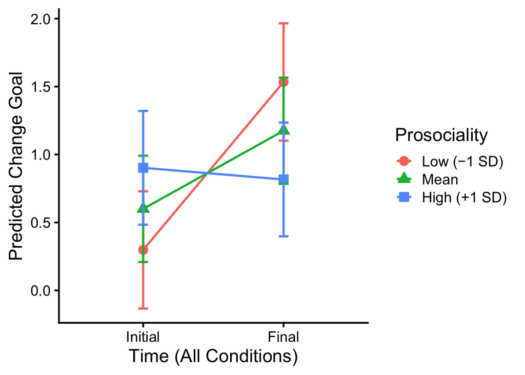

```r
#---------------------------------
# Graph - line graph
#---------------------------------
# Estimated marginal means
emm <- emmeans(model_all,
               ~ time_all_conditions | prosociality,
               at = list(prosociality = c(
                 mean(mot_clean$prosociality, na.rm = TRUE) -
                   sd(mot_clean$prosociality, na.rm = TRUE),
                 mean(mot_clean$prosociality, na.rm = TRUE),
                 mean(mot_clean$prosociality, na.rm = TRUE) +
                   sd(mot_clean$prosociality, na.rm = TRUE)
               )))
emm_df <- as.data.frame(emm)

# Factor prosociality levels and time points
emm_df$prosociality_f <- factor(emm_df$prosociality,
                                labels = c("Low (−1 SD)", "Mean", "High (+1 SD)"))
emm_df$time_all_conditions <- factor(emm_df$time_all_conditions, levels = c("Initial", "Final"))

# Create graph using the estimated marginal means
all_conditions_plot <- ggplot(
  emm_df,
  aes(
    x = time_all_conditions,
    y = emmean,
    group = prosociality_f,
    color = prosociality_f,
    shape = prosociality_f
  )
) +
  geom_line(linewidth = 1) +
  geom_point(size = 4) +
  geom_errorbar(aes(ymin = lower.CL, ymax = upper.CL),
                width = 0.07,
                linewidth = 1.0) +
  labs(
    x = "Time (All Conditions)",
    y = "Predicted Change Goal",
    color = "Prosociality",
    shape = "Prosociality"
  ) +
  theme_classic(base_size = 17.5)

# Print graph
all_conditions_plot
```

### 5.1.3 Estimated marginal means

```r
# Define the low and high prosociality
pros_levels <- c(
  mean(mot_clean$prosociality, na.rm = TRUE) -
    sd(mot_clean$prosociality, na.rm = TRUE),
  mean(mot_clean$prosociality, na.rm = TRUE),
  mean(mot_clean$prosociality, na.rm = TRUE) +
    sd(mot_clean$prosociality, na.rm = TRUE)
)
pros_labels <- c("Low Prosociality", "Mean Prosociality", "High Prosociality")

# Estimated marginal means
emm <- emmeans(model_all,
               ~ time_all_conditions | prosociality,
               at = list(prosociality = pros_levels))
contrast(emm, method = "pairwise")
```

```
## prosociality = 2.79:
##  contrast        estimate     SE  df t.ratio p.value
##  Initial - Final  -1.2359 0.1220 198 -10.131  <.0001
##
## prosociality = 3.51:
##  contrast        estimate     SE  df t.ratio p.value
##  Initial - Final  -0.5750 0.0862 198  -6.674  <.0001
##
## prosociality = 4.23:
##  contrast        estimate     SE  df t.ratio p.value
##  Initial - Final   0.0859 0.1220 198   0.705  0.4819
##
## Results are averaged over the levels of: gender
## Degrees-of-freedom method: kenward-roger
```

```r
emm_df <- as.data.frame(emm) %>%
  mutate(prosoc_group = factor(prosociality, levels = pros_levels, labels = pros_labels))

# Pairwise time contrast within each prosociality value
con_df <- contrast(emm, method = "pairwise") %>%
  as.data.frame() %>%
  mutate(prosoc_group = factor(prosociality, levels = pros_levels, labels = pros_labels))
```

## 5.2 Feedback condition

Compare the change goals before and after the feedback condition.

Only include the participants who completed the feedback condition first (n = 102).

### 5.2.1 Models

```r
#---------------------------------
# Prep
#---------------------------------
# Transform MEM_var from long to wide
mot_feedback <- MEM_var %>%
  pivot_longer(
    cols = c(change_goal_pre_feedback, change_goal_post_feedback),
    names_to = "time_feedback",
    values_to = "change_goal_feedback"
  ) %>%
  mutate(
    time_feedback = dplyr::recode(
      time_feedback,
      change_goal_pre_feedback  = "Pre-feedback",
      change_goal_post_feedback = "Post-feedback"
    )
  )

# Factor time and reorder
mot_feedback$time_feedback <- factor(
  mot_feedback$time_feedback,
  levels = c("Pre-feedback", "Post-feedback")
)
# Keep only when the participant completed the feedback condition first
mot_feedback <- mot_feedback %>%
  filter(feedback_first == 1)

#---------------------------------
# Models
#---------------------------------
# ----- Standardize -----
mot_feedback_z <- mot_feedback

# z-score outcome + continuous predictors
mot_feedback_z$change_z        <- as.numeric(scale(mot_feedback_z$change_goal_feedback))
mot_feedback_z$prosociality_z  <- as.numeric(scale(mot_feedback_z$prosociality))
mot_feedback_z$age_z           <- as.numeric(scale(mot_feedback_z$age))
mot_feedback_z$income_z        <- as.numeric(scale(mot_feedback_z$income))

# ----- Baseline models -----
model_empty_z <- lmer(change_z ~ 1 +
                        (1 | participant_id), data = mot_feedback_z)
summary(model_empty_z)
```

```
## Linear mixed model fit by REML. t-tests use Satterthwaite's method [
## lmerModLmerTest]
## Formula: change_z ~ 1 + (1 | participant_id)
##    Data: mot_feedback_z
##
## REML criterion at convergence: 558.3
##
## Scaled residuals:
##      Min       1Q   Median       3Q      Max
## -2.91248 -0.35166  0.05595  0.46355  1.87466
##
## Random effects:
##  Groups         Name        Variance Std.Dev.
##  participant_id (Intercept) 0.4518   0.6721
##  Residual                   0.5505   0.7419
## Number of obs: 204, groups:  participant_id, 102
##
## Fixed effects:
##              Estimate Std. Error        df t value Pr(>|t|)
## (Intercept) 1.340e-16  8.442e-02 1.010e+02       0        1
```

```r
model_control_z <- lmer(change_z ~ age_z + gender + income_z +
                          (1 |
                             participant_id), data = mot_feedback_z)
summary(model_control_z)
```

```
## Linear mixed model fit by REML. t-tests use Satterthwaite's method [
## lmerModLmerTest]
## Formula: change_z ~ age_z + gender + income_z + (1 | participant_id)
##    Data: mot_feedback_z
##
## REML criterion at convergence: 564
##
## Scaled residuals:
##      Min       1Q   Median       3Q      Max
## -2.88558 -0.41342  0.02758  0.46820  1.94700
##
## Random effects:
##  Groups         Name        Variance Std.Dev.
##  participant_id (Intercept) 0.4572   0.6762
##  Residual                   0.5505   0.7419
## Number of obs: 204, groups:  participant_id, 102
##
## Fixed effects:
##             Estimate Std. Error       df t value Pr(>|t|)
## (Intercept)  0.02750    0.12379 98.00000   0.222    0.825
## age_z       -0.09068    0.08542 98.00000  -1.062    0.291
## genderMale  -0.05194    0.17044 98.00000  -0.305    0.761
## income_z     0.09346    0.08511 98.00000   1.098    0.275
##
## Correlation of Fixed Effects:
##            (Intr) age_z  gndrMl
## age_z      -0.064
## genderMale -0.729  0.087
## income_z    0.012 -0.059 -0.016
```

```r
model_x_interaction_z <- lmer(
  change_z ~ time_feedback + prosociality_z +
    age_z + gender + income_z +
    (1 | participant_id),
  data = mot_feedback_z
)
summary(model_x_interaction_z)
```

```
## Linear mixed model fit by REML. t-tests use Satterthwaite's method [
## lmerModLmerTest]
## Formula: change_z ~ time_feedback + prosociality_z + age_z + gender +
##     income_z + (1 | participant_id)
##    Data: mot_feedback_z
##
## REML criterion at convergence: 567.8
##
## Scaled residuals:
##      Min       1Q   Median       3Q      Max
## -2.90502 -0.45591 -0.01085  0.55203  1.86766
##
## Random effects:
##  Groups         Name        Variance Std.Dev.
##  participant_id (Intercept) 0.4543   0.6740
##  Residual                   0.5528   0.7435
## Number of obs: 204, groups:  participant_id, 102
##
## Fixed effects:
##                             Estimate Std. Error        df t value Pr(>|t|)
## (Intercept)                  0.07664    0.13445 130.33757   0.570    0.570
## time_feedbackPost-feedback  -0.07831    0.10411 101.00000  -0.752    0.454
## prosociality_z               0.10003    0.08985  97.00000   1.113    0.268
## age_z                       -0.12240    0.08995  97.00000  -1.361    0.177
## genderMale                  -0.07081    0.17107  97.00000  -0.414    0.680
## income_z                     0.10209    0.08535  97.00000   1.196    0.235
##
## Correlation of Fixed Effects:
##             (Intr) tm_fP- prscl_ age_z  gndrMl
## tm_fdbckPs- -0.387
## prosoclty_z  0.067  0.000
## age_z       -0.077  0.000 -0.317
## genderMale  -0.674  0.000 -0.099  0.114
## income_z     0.017  0.000  0.091 -0.085 -0.025
```

```r
model_time_z <- lmer(
  change_z ~ time_feedback +
    age_z + gender + income_z +
    (1 | participant_id),
  data = mot_feedback_z
)
summary(model_time_z)
```

```
## Linear mixed model fit by REML. t-tests use Satterthwaite's method [
## lmerModLmerTest]
## Formula:
## change_z ~ time_feedback + age_z + gender + income_z + (1 | participant_id)
##    Data: mot_feedback_z
##
## REML criterion at convergence: 566.1
##
## Scaled residuals:
##      Min       1Q   Median       3Q      Max
## -2.93521 -0.44301 -0.01581  0.51957  1.89161
##
## Random effects:
##  Groups         Name        Variance Std.Dev.
##  participant_id (Intercept) 0.4561   0.6753
##  Residual                   0.5528   0.7435
## Number of obs: 204, groups:  participant_id, 102
##
## Fixed effects:
##                             Estimate Std. Error        df t value Pr(>|t|)
## (Intercept)                  0.06665    0.13429 131.73132   0.496    0.620
## time_feedbackPost-feedback  -0.07831    0.10411 101.00000  -0.752    0.454
## age_z                       -0.09068    0.08542  98.00000  -1.062    0.291
## genderMale                  -0.05194    0.17044  98.00000  -0.305    0.761
## income_z                     0.09346    0.08511  98.00000   1.098    0.275
##
## Correlation of Fixed Effects:
##             (Intr) tm_fP- age_z  gndrMl
## tm_fdbckPs- -0.388
## age_z       -0.059  0.000
## genderMale  -0.672  0.000  0.087
## income_z     0.011  0.000 -0.059 -0.016
```

```r
# ----- Interaction Model - standardized -----
# Time x prosocial model
model_feedback_z <- lmer(
  change_z ~ time_feedback * prosociality_z + age_z + gender + income_z + (1 |
                                                                             participant_id),
  data = mot_feedback_z
)

summary(model_feedback_z)
```

```
## Linear mixed model fit by REML. t-tests use Satterthwaite's method [
## lmerModLmerTest]
## Formula: change_z ~ time_feedback * prosociality_z + age_z + gender +
##     income_z + (1 | participant_id)
##    Data: mot_feedback_z
##
## REML criterion at convergence: 548.9
##
## Scaled residuals:
##      Min       1Q   Median       3Q      Max
## -2.84733 -0.48216  0.03103  0.52443  1.90804
##
## Random effects:
##  Groups         Name        Variance Std.Dev.
##  participant_id (Intercept) 0.5058   0.7112
##  Residual                   0.4498   0.6707
## Number of obs: 204, groups:  participant_id, 102
##
## Fixed effects:
##                                            Estimate Std. Error        df
## (Intercept)                                 0.07664    0.13255 124.34998
## time_feedbackPost-feedback                 -0.07831    0.09391 100.00000
## prosociality_z                              0.33130    0.10144 146.81913
## age_z                                      -0.12240    0.08995  97.00000
## genderMale                                 -0.07081    0.17107  97.00000
## income_z                                    0.10209    0.08535  97.00000
## time_feedbackPost-feedback:prosociality_z  -0.46254    0.09414 100.00000
##                                           t value Pr(>|t|)
## (Intercept)                                 0.578  0.56418
## time_feedbackPost-feedback                 -0.834  0.40633
## prosociality_z                              3.266  0.00136 **
## age_z                                      -1.361  0.17674
## genderMale                                 -0.414  0.67986
## income_z                                    1.196  0.23458
## time_feedbackPost-feedback:prosociality_z  -4.913  3.5e-06 ***
## ---
## Signif. codes:  0 '***' 0.001 '**' 0.01 '*' 0.05 '.' 0.1 ' ' 1
##
## Correlation of Fixed Effects:
##             (Intr) tm_fP- prscl_ age_z  gndrMl incm_z
## tm_fdbckPs- -0.354
## prosoclty_z  0.060  0.000
## age_z       -0.078  0.000 -0.281
## genderMale  -0.683  0.000 -0.088  0.114
## income_z     0.017  0.000  0.080 -0.085 -0.025
## tm_fdbcP-:_  0.000  0.000 -0.464  0.000  0.000  0.000
```

```r
tab_model(
  model_feedback_z,
  show.se = TRUE,
  show.stat = TRUE,
  show.ci = FALSE,
  p.style = "numeric",
  show.aic = FALSE,
  show.icc = FALSE,
  string.est = "Estimate",
  string.se = "SE",
  string.stat = "t",
  string.p = "p"
)
```

|  | change_z |  |  |  |
| --- | --- | --- | --- | --- |
| Predictors | Estimate | SE | t | p |
| (Intercept) | 0.08 | 0.13 | 0.58 | 0.564 |
| time feedback [Post-feedback] | -0.08 | 0.09 | -0.83 | 0.405 |
| prosociality z | 0.33 | 0.10 | 3.27 | **0.001** |
| age z | -0.12 | 0.09 | -1.36 | 0.175 |
| gender [Male] | -0.07 | 0.17 | -0.41 | 0.679 |
| income z | 0.10 | 0.09 | 1.20 | 0.233 |
| time feedback [Post-feedback] × prosociality z | -0.46 | 0.09 | -4.91 | **<0.001** |
| Random Effects |  |  |  |  |
| σ<sup>2</sup> | 0.45 |  |  |  |
| τ<sub>00</sub> <sub>participant_id</sub> | 0.51 |  |  |  |
| N <sub>participant_id</sub> | 102 |  |  |  |
| Observations | 204 |  |  |  |
| Marginal R<sup>2</sup> / Conditional R<sup>2</sup> | 0.077 / 0.566 |  |  |  |

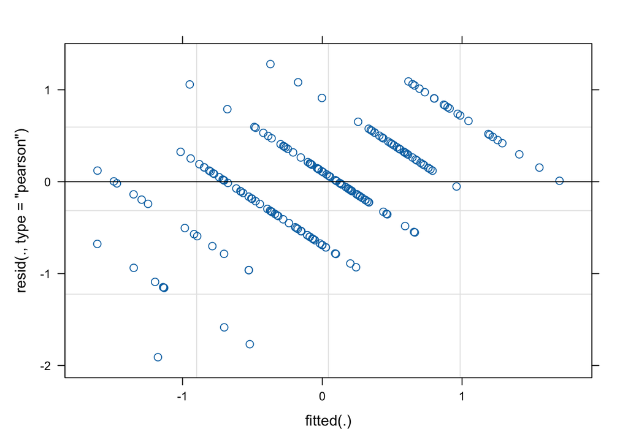

```r
# Check assumptions
plot(model_feedback_z)
```

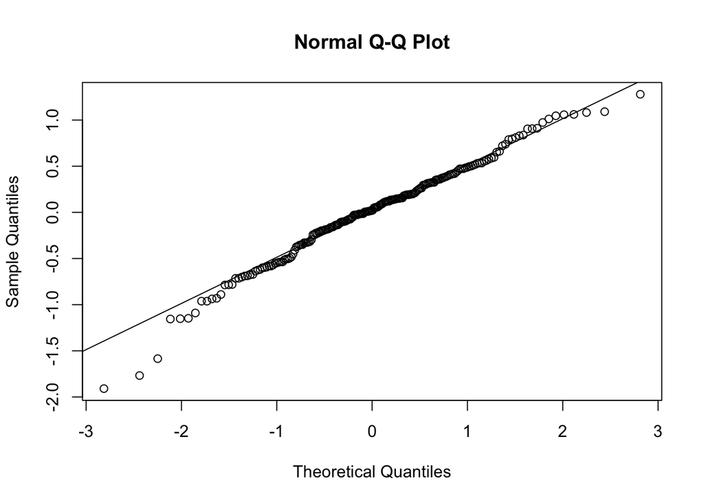

```r
qqnorm(resid(model_feedback_z))
qqline(resid(model_feedback_z))
```

```r
# ----- Interaction Model - non-standardized-----
# Time x prosocial model
model_feedback <- lmer(
  change_goal_feedback ~ time_feedback * prosociality +
    age + gender + income +
    (1 | participant_id),
  data = mot_feedback
)

summary(model_feedback)
```

```
## Linear mixed model fit by REML. t-tests use Satterthwaite's method [
## lmerModLmerTest]
## Formula: change_goal_feedback ~ time_feedback * prosociality + age + gender +
##     income + (1 | participant_id)
##    Data: mot_feedback
##
## REML criterion at convergence: 642
##
## Scaled residuals:
##      Min       1Q   Median       3Q      Max
## -2.84733 -0.48216  0.03103  0.52443  1.90804
##
## Random effects:
##  Groups         Name        Variance Std.Dev.
##  participant_id (Intercept) 0.7927   0.8904
##  Residual                   0.7049   0.8396
## Number of obs: 204, groups:  participant_id, 102
##
## Fixed effects:
##                                          Estimate Std. Error        df t value
## (Intercept)                              -0.94608    0.76872 128.84428  -1.231
## time_feedbackPost-feedback                2.70966    0.58342 100.00000   4.644
## prosociality                              0.56030    0.17155 146.81913   3.266
## age                                      -0.01487    0.01093  97.00000  -1.361
## genderMale                               -0.08864    0.21416  97.00000  -0.414
## income                                    0.07259    0.06069  97.00000   1.196
## time_feedbackPost-feedback:prosociality  -0.78226    0.15921 100.00000  -4.913
##                                         Pr(>|t|)
## (Intercept)                              0.22067
## time_feedbackPost-feedback              1.04e-05 ***
## prosociality                             0.00136 **
## age                                      0.17674
## genderMale                               0.67986
## income                                   0.23458
## time_feedbackPost-feedback:prosociality 3.50e-06 ***
## ---
## Signif. codes:  0 '***' 0.001 '**' 0.01 '*' 0.05 '.' 0.1 ' ' 1
##
## Correlation of Fixed Effects:
##             (Intr) tm_fP- prsclt age    gndrMl income
## tm_fdbckPs- -0.379
## prosocialty -0.676  0.455
## age         -0.291  0.000 -0.281
## genderMale  -0.126  0.000 -0.088  0.114
## income      -0.515  0.000  0.080 -0.085 -0.025
## tm_fdbckP-:  0.372 -0.979 -0.464  0.000  0.000  0.000
```

### 5.2.2 Graph

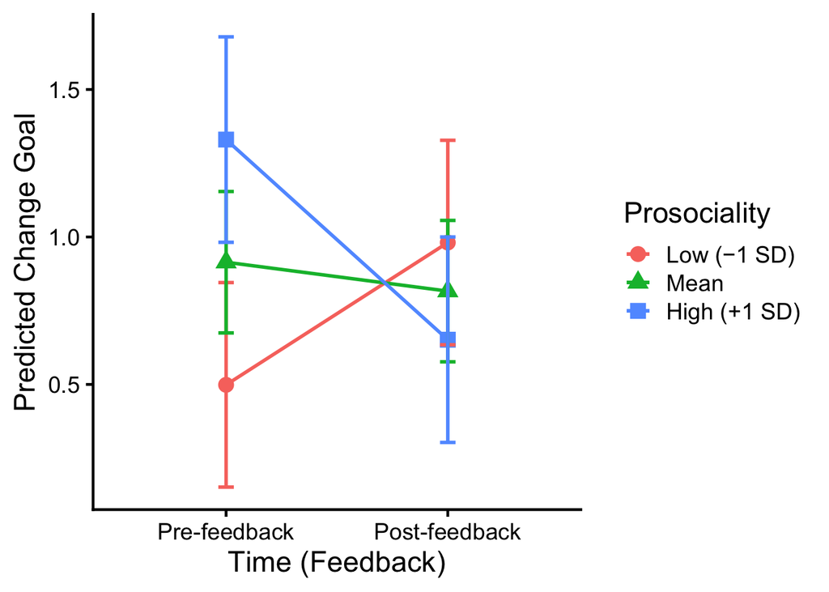

```r
#---------------------------------
# Prep
#---------------------------------
# Subset mot_all for accurate prosociality sd calculation of this subgroup
# Keep only when the participant completed the feedback condition first
mot_feedback_wide <- mot_clean %>%
  filter(feedback_first == 1)

#---------------------------------
# Graph - line graph
#---------------------------------
# Estimated marginal means
emm <- emmeans(model_feedback,
               ~ time_feedback | prosociality,
               at = list(prosociality = c(
                 mean(mot_feedback_wide$prosociality, na.rm = TRUE) -
                   sd(mot_feedback_wide$prosociality, na.rm = TRUE),
                 mean(mot_feedback_wide$prosociality, na.rm = TRUE),
                 mean(mot_feedback_wide$prosociality, na.rm = TRUE) +
                   sd(mot_feedback_wide$prosociality, na.rm = TRUE)
               )))
emm_df <- as.data.frame(emm)

# Factor prosociality levels and time points
emm_df$prosociality_f <- factor(emm_df$prosociality,
                                labels = c("Low (−1 SD)", "Mean", "High (+1 SD)"))
emm_df$time_feedback <- factor(emm_df$time_feedback, levels = c("Pre-feedback", "Post-feedback"))

# Create graph using the estimated marginal means
feedback_condition_plot <- ggplot(
  emm_df,
  aes(
    x = time_feedback,
    y = emmean,
    group = prosociality_f,
    color = prosociality_f,
    shape = prosociality_f
  )
) +
  geom_line(linewidth = 1) +
  geom_point(size = 4) +
  geom_errorbar(aes(ymin = lower.CL, ymax = upper.CL),
                width = 0.07,
                linewidth = 1.0) +
  labs(
    x = "Time (Feedback)",
    y = "Predicted Change Goal",
    color = "Prosociality",
    shape = "Prosociality"
  ) +
  theme_classic(base_size = 17.5)

# Print graph
feedback_condition_plot
```

### 5.2.3 Estimated marginal means

```r
# Define the low and high prosociality
pros_levels <- c(
  mean(mot_feedback_wide$prosociality, na.rm = TRUE) -
    sd(mot_feedback_wide$prosociality, na.rm = TRUE),
  mean(mot_feedback_wide$prosociality, na.rm = TRUE),
  mean(mot_feedback_wide$prosociality, na.rm = TRUE) +
    sd(mot_feedback_wide$prosociality, na.rm = TRUE)
)
pros_labels <- c("Low Prosociality", "Mean Prosociality", "High Prosociality")

# Estimated marginal means
emm <- emmeans(model_feedback,
               ~ time_feedback | prosociality,
               at = list(prosociality = pros_levels))
contrast(emm, method = "pairwise")
```

```
## prosociality = 2.85:
##  contrast                         estimate    SE  df t.ratio p.value
##  (Pre-feedback) - (Post-feedback)   -0.482 0.167 100  -2.895  0.0047
##
## prosociality = 3.59:
##  contrast                         estimate    SE  df t.ratio p.value
##  (Pre-feedback) - (Post-feedback)    0.098 0.118 100   0.834  0.4063
##
## prosociality = 4.33:
##  contrast                         estimate    SE  df t.ratio p.value
##  (Pre-feedback) - (Post-feedback)    0.679 0.167 100   4.071  0.0001
##
## Results are averaged over the levels of: gender
## Degrees-of-freedom method: kenward-roger
```

```r
emm_df <- as.data.frame(emm) %>%
  mutate(prosoc_group = factor(prosociality, levels = pros_levels, labels = pros_labels))

# Pairwise time contrast within each prosociality value
con_df <- contrast(emm, method = "pairwise") %>%
  as.data.frame() %>%
  mutate(prosoc_group = factor(prosociality, levels = pros_levels, labels = pros_labels))
```

## 5.3 Psychoed condition

Compare the change goals before and after the psychoed condition.

Only include the participants who completed the psychoed condition first (n = 98).

### 5.3.1 Models

```r
#---------------------------------
# Prep
#---------------------------------
# Transform MEM_var from long to wide
mot_psychoed <- MEM_var %>%
  pivot_longer(
    cols = c(change_goal_pre_psychoed, change_goal_post_psychoed),
    names_to = "time_psychoed",
    values_to = "change_goal_psychoed"
  ) %>%
  mutate(
    time_psychoed = dplyr::recode(
      time_psychoed,
      change_goal_pre_psychoed  = "Pre-psychoed",
      change_goal_post_psychoed = "Post-psychoed"
    )
  )

# Factor time and reorder
mot_psychoed$time_psychoed <- factor(mot_psychoed$time_psychoed,
                                         levels = c("Pre-psychoed", "Post-psychoed"))
# Keep only when the participant completed the psychoed condition first
mot_psychoed <- mot_psychoed %>%
  filter(feedback_first == 0)

#---------------------------------
# Models
#---------------------------------
# ----- Standardize -----
mot_psychoed_z <- mot_psychoed

# z-score outcome + continuous predictors
mot_psychoed_z$change_z        <- as.numeric(scale(mot_psychoed_z$change_goal_psychoed))
mot_psychoed_z$prosociality_z  <- as.numeric(scale(mot_psychoed_z$prosociality))
mot_psychoed_z$age_z           <- as.numeric(scale(mot_psychoed_z$age))
mot_psychoed_z$income_z        <- as.numeric(scale(mot_psychoed_z$income))

# ----- Baseline models -----
model_empty_z <- lmer(change_z ~ 1 +
                        (1 |
                           participant_id), data = mot_psychoed_z)
summary(model_empty_z)
```

```
## Linear mixed model fit by REML. t-tests use Satterthwaite's method [
## lmerModLmerTest]
## Formula: change_z ~ 1 + (1 | participant_id)
##    Data: mot_psychoed_z
##
## REML criterion at convergence: 551.6
##
## Scaled residuals:
##      Min       1Q   Median       3Q      Max
## -2.63597 -0.67557 -0.00247  0.67064  1.85556
##
## Random effects:
##  Groups         Name        Variance Std.Dev.
##  participant_id (Intercept) 0.2644   0.5142
##  Residual                   0.7370   0.8585
## Number of obs: 196, groups:  participant_id, 98
##
## Fixed effects:
##              Estimate Std. Error        df t value Pr(>|t|)
## (Intercept) 2.014e-16  8.036e-02 9.700e+01       0        1
```

```r
model_control_z <- lmer(change_z ~ age_z + gender + income_z +
                          (1 |
                             participant_id), data = mot_psychoed_z)
summary(model_control_z)
```

```
## Linear mixed model fit by REML. t-tests use Satterthwaite's method [
## lmerModLmerTest]
## Formula: change_z ~ age_z + gender + income_z + (1 | participant_id)
##    Data: mot_psychoed_z
##
## REML criterion at convergence: 548
##
## Scaled residuals:
##      Min       1Q   Median       3Q      Max
## -2.79968 -0.47915  0.09889  0.60635  1.92477
##
## Random effects:
##  Groups         Name        Variance Std.Dev.
##  participant_id (Intercept) 0.2155   0.4642
##  Residual                   0.7370   0.8585
## Number of obs: 196, groups:  participant_id, 98
##
## Fixed effects:
##                 Estimate Std. Error       df t value Pr(>|t|)
## (Intercept)     -0.02403    0.10825 93.00000  -0.222  0.82478
## age_z           -0.23619    0.07833 93.00000  -3.016  0.00331 **
## genderMale       0.09875    0.15729 93.00000   0.628  0.53165
## genderNonbinary -0.69612    0.45958 93.00000  -1.515  0.13324
## income_z        -0.08110    0.07777 93.00000  -1.043  0.29974
## ---
## Signif. codes:  0 '***' 0.001 '**' 0.01 '*' 0.05 '.' 0.1 ' ' 1
##
## Correlation of Fixed Effects:
##             (Intr) age_z  gndrMl gndrNn
## age_z       -0.048
## genderMale  -0.689  0.046
## gendrNnbnry -0.244  0.134  0.170
## income_z     0.030  0.063 -0.032 -0.063
```

```r
model_x_interaction_z <- lmer(
  change_z ~ time_psychoed + prosociality_z +
    age_z + gender + income_z +
    (1 | participant_id),
  data = mot_psychoed_z
)
summary(model_x_interaction_z)
```

```
## Linear mixed model fit by REML. t-tests use Satterthwaite's method [
## lmerModLmerTest]
## Formula: change_z ~ time_psychoed + prosociality_z + age_z + gender +
##     income_z + (1 | participant_id)
##    Data: mot_psychoed_z
##
## REML criterion at convergence: 524.2
##
## Scaled residuals:
##      Min       1Q   Median       3Q      Max
## -2.70995 -0.50005  0.07015  0.60770  2.65490
##
## Random effects:
##  Groups         Name        Variance Std.Dev.
##  participant_id (Intercept) 0.3131   0.5596
##  Residual                   0.5515   0.7426
## Number of obs: 196, groups:  participant_id, 98
##
## Fixed effects:
##                             Estimate Std. Error        df t value Pr(>|t|)
## (Intercept)                 -0.32806    0.12143 133.46787  -2.702  0.00780 **
## time_psychoedPost-psychoed   0.61823    0.10609  97.00000   5.827 7.35e-08 ***
## prosociality_z               0.03903    0.08221  92.00000   0.475  0.63607
## age_z                       -0.24756    0.08222  92.00000  -3.011  0.00336 **
## genderMale                   0.08929    0.15920  92.00000   0.561  0.57624
## genderNonbinary             -0.72042    0.46433  92.00000  -1.552  0.12421
## income_z                    -0.07769    0.07843  92.00000  -0.991  0.32450
## ---
## Signif. codes:  0 '***' 0.001 '**' 0.01 '*' 0.05 '.' 0.1 ' ' 1
##
## Correlation of Fixed Effects:
##             (Intr) tm_pP- prscl_ age_z  gndrMl gndrNn
## tm_psychdP- -0.437
## prosoclty_z  0.088  0.000
## age_z       -0.067  0.000 -0.291
## genderMale  -0.623  0.000 -0.125  0.080
## gendrNnbnry -0.226  0.000 -0.110  0.160  0.182
## income_z     0.034  0.000  0.092  0.033 -0.043 -0.073
```

```r
# ----- Interaction Model - standardized -----
# Time x prosocial model
model_psychoed_z <- lmer(
  change_z ~ time_psychoed * prosociality_z + age_z + gender + income_z + (1 |
                                                                               participant_id),
  data = mot_psychoed_z
)
summary(model_psychoed_z)
```

```
## Linear mixed model fit by REML. t-tests use Satterthwaite's method [
## lmerModLmerTest]
## Formula: change_z ~ time_psychoed * prosociality_z + age_z + gender +
##     income_z + (1 | participant_id)
##    Data: mot_psychoed_z
##
## REML criterion at convergence: 522.7
##
## Scaled residuals:
##      Min       1Q   Median       3Q      Max
## -2.80182 -0.50285  0.03162  0.56170  2.74764
##
## Random effects:
##  Groups         Name        Variance Std.Dev.
##  participant_id (Intercept) 0.3218   0.5673
##  Residual                   0.5341   0.7308
## Number of obs: 196, groups:  participant_id, 98
##
## Fixed effects:
##                                            Estimate Std. Error        df
## (Intercept)                                -0.32806    0.12107 132.20879
## time_psychoedPost-psychoed                  0.61823    0.10440  96.00000
## prosociality_z                              0.14589    0.09745 156.97339
## age_z                                      -0.24756    0.08222  92.00000
## genderMale                                  0.08929    0.15920  92.00000
## genderNonbinary                            -0.72042    0.46433  92.00000
## income_z                                   -0.07769    0.07843  92.00000
## time_psychoedPost-psychoed:prosociality_z  -0.21373    0.10467  96.00000
##                                           t value Pr(>|t|)
## (Intercept)                                -2.710  0.00763 **
## time_psychoedPost-psychoed                  5.922 4.94e-08 ***
## prosociality_z                              1.497  0.13637
## age_z                                      -3.011  0.00336 **
## genderMale                                  0.561  0.57624
## genderNonbinary                            -1.552  0.12421
## income_z                                   -0.991  0.32450
## time_psychoedPost-psychoed:prosociality_z  -2.042  0.04390 *
## ---
## Signif. codes:  0 '***' 0.001 '**' 0.01 '*' 0.05 '.' 0.1 ' ' 1
##
## Correlation of Fixed Effects:
##             (Intr) tm_pP- prscl_ age_z  gndrMl gndrNn incm_z
## tm_psychdP- -0.431
## prosoclty_z  0.075  0.000
## age_z       -0.067  0.000 -0.246
## genderMale  -0.625  0.000 -0.106  0.080
## gendrNnbnry -0.227  0.000 -0.093  0.160  0.182
## income_z     0.034  0.000  0.077  0.033 -0.043 -0.073
## tm_psycP-:_  0.000  0.000 -0.537  0.000  0.000  0.000  0.000
```

```r
tab_model(
  model_psychoed_z,
  show.se = TRUE,
  show.stat = TRUE,
  show.ci = FALSE,
  p.style = "numeric",
  show.aic = FALSE,
  show.icc = FALSE,
  string.est = "Estimate",
  string.se = "SE",
  string.stat = "t",
  string.p = "p"
)
```

|  | change_z |  |  |  |
| --- | --- | --- | --- | --- |
| Predictors | Estimate | SE | t | p |
| (Intercept) | -0.33 | 0.12 | -2.71 | **0.007** |
| time psychoed [Post-psychoed] | 0.62 | 0.10 | 5.92 | **<0.001** |
| prosociality z | 0.15 | 0.10 | 1.50 | 0.136 |
| age z | -0.25 | 0.08 | -3.01 | **0.003** |
| gender [Male] | 0.09 | 0.16 | 0.56 | 0.576 |
| gender [Nonbinary] | -0.72 | 0.46 | -1.55 | 0.122 |
| income z | -0.08 | 0.08 | -0.99 | 0.323 |
| time psychoed [Post-psychoed] × prosociality z | -0.21 | 0.10 | -2.04 | **0.043** |
| Random Effects |  |  |  |  |
| σ<sup>2</sup> | 0.53 |  |  |  |
| τ<sub>00</sub> <sub>participant_id</sub> | 0.32 |  |  |  |
| N <sub>participant_id</sub> | 98 |  |  |  |
| Observations | 196 |  |  |  |
| Marginal R<sup>2</sup> / Conditional R<sup>2</sup> | 0.175 / 0.485 |  |  |  |

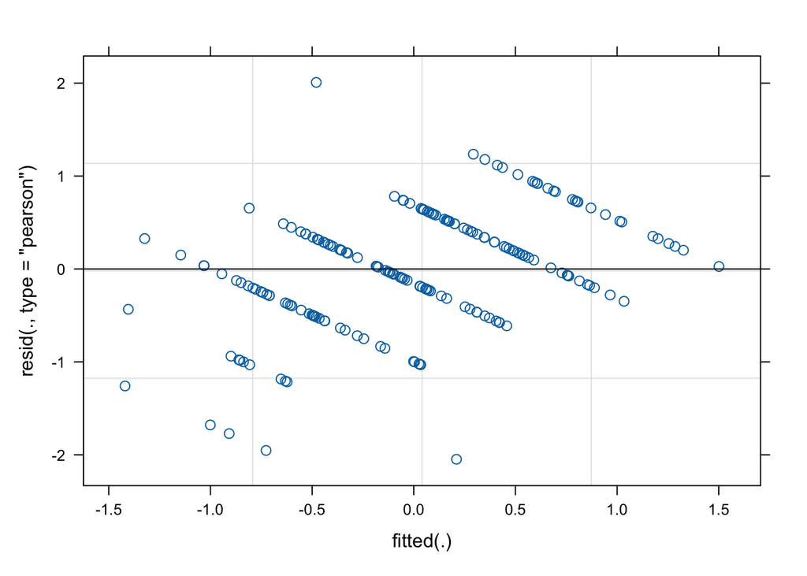

```r
# Check assumptions
plot(model_psychoed_z)
```

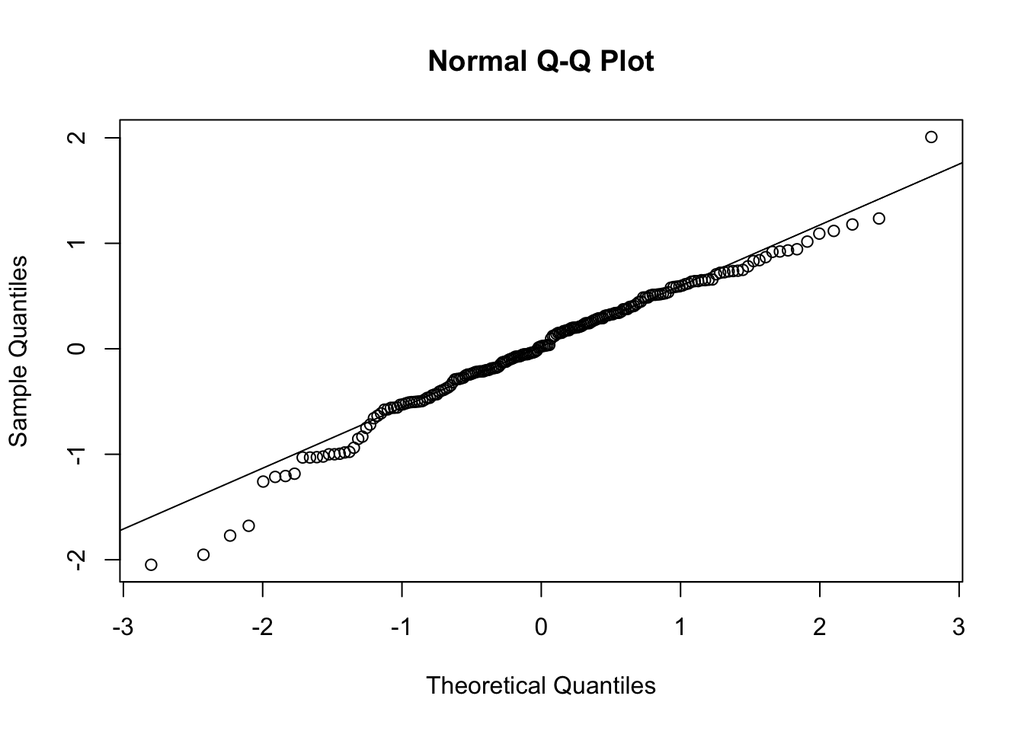

```r
qqnorm(resid(model_psychoed_z))
qqline(resid(model_psychoed_z))
```

```r
# ----- Interaction Model - non-standardized-----
# Time x prosocial model
model_psychoed <- lmer(
  change_goal_psychoed ~ time_psychoed * prosociality +
    age + gender + income +
    (1 | participant_id),
  data = mot_psychoed
)

summary(model_psychoed)
```

```
## Linear mixed model fit by REML. t-tests use Satterthwaite's method [
## lmerModLmerTest]
## Formula: change_goal_psychoed ~ time_psychoed * prosociality + age + gender +
##     income + (1 | participant_id)
##    Data: mot_psychoed
##
## REML criterion at convergence: 592
##
## Scaled residuals:
##      Min       1Q   Median       3Q      Max
## -2.80182 -0.50285  0.03162  0.56170  2.74764
##
## Random effects:
##  Groups         Name        Variance Std.Dev.
##  participant_id (Intercept) 0.4545   0.6742
##  Residual                   0.7542   0.8685
## Number of obs: 196, groups:  participant_id, 98
##
## Fixed effects:
##                                           Estimate Std. Error         df
## (Intercept)                               1.268199   0.717750 133.496407
## time_psychoedPost-psychoed                1.991241   0.627738  96.000000
## prosociality                              0.249950   0.166955 156.973392
## age                                      -0.026770   0.008891  92.000000
## genderMale                                0.106111   0.189186  92.000000
## genderNonbinary                          -0.856137   0.551804  92.000000
## income                                   -0.054429   0.054948  92.000000
## time_psychoedPost-psychoed:prosociality  -0.366166   0.179319  96.000000
##                                         t value Pr(>|t|)
## (Intercept)                               1.767  0.07953 .
## time_psychoedPost-psychoed                3.172  0.00203 **
## prosociality                              1.497  0.13637
## age                                      -3.011  0.00336 **
## genderMale                                0.561  0.57624
## genderNonbinary                          -1.552  0.12421
## income                                   -0.991  0.32450
## time_psychoedPost-psychoed:prosociality  -2.042  0.04390 *
## ---
## Signif. codes:  0 '***' 0.001 '**' 0.01 '*' 0.05 '.' 0.1 ' ' 1
##
## Correlation of Fixed Effects:
##             (Intr) tm_pP- prsclt age    gndrMl gndrNn income
## tm_psychdP- -0.437
## prosocialty -0.709  0.526
## age         -0.290  0.000 -0.246
## genderMale  -0.057  0.000 -0.106  0.080
## gendrNnbnry -0.009  0.000 -0.093  0.160  0.182
## income      -0.557  0.000  0.077  0.033 -0.043 -0.073
## tm_psychP-:  0.429 -0.980 -0.537  0.000  0.000  0.000  0.000
```

### 5.3.2 Graph

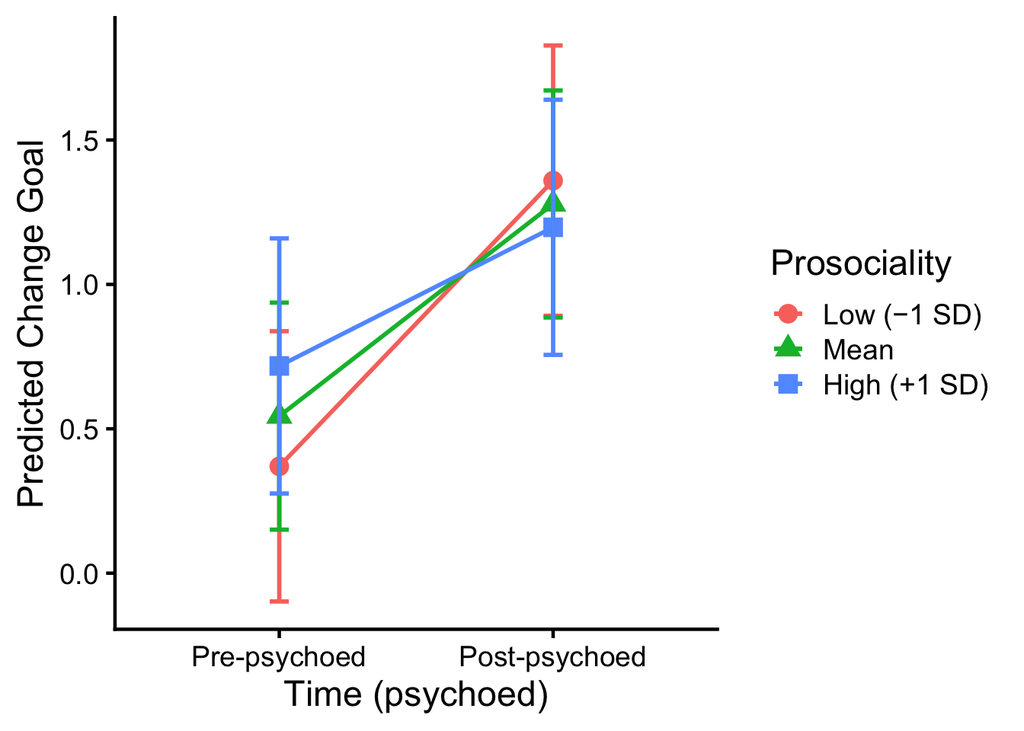

```r
#---------------------------------
# Prep
#---------------------------------
# Subset mot_all for accurate prosociality sd calculation of this subgroup
# Keep only when the participant completed the psychoed condition first
mot_psychoed_wide <- mot_clean %>%
  filter(feedback_first == 0)

#---------------------------------
# Graph - line graph
#---------------------------------
# Estimated marginal means
emm <- emmeans(model_psychoed,
               ~ time_psychoed | prosociality,
               at = list(prosociality = c(
                 mean(mot_psychoed_wide$prosociality, na.rm = TRUE) -
                   sd(mot_psychoed_wide$prosociality, na.rm = TRUE),
                 mean(mot_psychoed_wide$prosociality, na.rm = TRUE),
                 mean(mot_psychoed_wide$prosociality, na.rm = TRUE) +
                   sd(mot_psychoed_wide$prosociality, na.rm = TRUE)
               )))
emm_df <- as.data.frame(emm)

# Factor prosociality levels and time points
emm_df$prosociality_f <- factor(emm_df$prosociality,
                                labels = c("Low (−1 SD)", "Mean", "High (+1 SD)"))
emm_df$time_psychoed <- factor(emm_df$time_psychoed,
                                 levels = c("Pre-psychoed", "Post-psychoed"))

# Create graph using the estimated marginal means
psychoed_condition_plot <- ggplot(
  emm_df,
  aes(
    x = time_psychoed,
    y = emmean,
    group = prosociality_f,
    color = prosociality_f,
    shape = prosociality_f
  )
) +
  geom_line(linewidth = 1) +
  geom_point(size = 4) +
  geom_errorbar(aes(ymin = lower.CL, ymax = upper.CL),
                width = 0.07,
                linewidth = 1.0) +
  labs(
    x = "Time (psychoed)",
    y = "Predicted Change Goal",
    color = "Prosociality",
    shape = "Prosociality"
  ) +
  theme_classic(base_size = 17.5)

# Print graph
psychoed_condition_plot
```

### 5.3.3 Estimated marginal means

```r
# Define the low and high prosociality
pros_levels <- c(
  mean(mot_psychoed_wide$prosociality, na.rm = TRUE) -
    sd(mot_psychoed_wide$prosociality, na.rm = TRUE),
  mean(mot_psychoed_wide$prosociality, na.rm = TRUE),
  mean(mot_psychoed_wide$prosociality, na.rm = TRUE) +
    sd(mot_psychoed_wide$prosociality, na.rm = TRUE)
)
pros_labels <- c("Low Prosociality", "Mean Prosociality", "High Prosociality")

# Estimated marginal means
emm <- emmeans(model_psychoed,
               ~ time_psychoed | prosociality,
               at = list(prosociality = pros_levels))
contrast(emm, method = "pairwise")
```

```
## prosociality = 2.74:
##  contrast                         estimate    SE df t.ratio p.value
##  (Pre-psychoed) - (Post-psychoed)   -0.989 0.176 96  -5.624  <.0001
##
## prosociality = 3.43:
##  contrast                         estimate    SE df t.ratio p.value
##  (Pre-psychoed) - (Post-psychoed)   -0.735 0.124 96  -5.922  <.0001
##
## prosociality = 4.13:
##  contrast                         estimate    SE df t.ratio p.value
##  (Pre-psychoed) - (Post-psychoed)   -0.480 0.176 96  -2.729  0.0076
##
## Results are averaged over the levels of: gender
## Degrees-of-freedom method: kenward-roger
```

```r
emm_df <- as.data.frame(emm) %>%
  mutate(prosoc_group = factor(prosociality, levels = pros_levels, labels = pros_labels))

# Pairwise time contrast within each prosociality value
con_df <- contrast(emm, method = "pairwise") %>%
  as.data.frame() %>%
  mutate(prosoc_group = factor(prosociality, levels = pros_levels, labels = pros_labels))
```

### 5.3.4 Motivational effectiveness of psychoeducational information

The following block tests whether the information we provided in the psychoed condition motivated people, and whether participants with different prosociality levels found them differently motivating.

```r
# List of the prosocial motivator variables
motivator <- c(
  "Mot_wellbeing",
  "Mot_stress",
  "Mot_religion",
  "Mot_moral",
  "Mot_emotion",
  "Mot_meaning",
  "Mot_health",
  "Mot_reputation",
  "Mot_connection",
  "Mot_better_friends",
  "Mot_job",
  "Mot_contagion",
  "Mot_romantic",
  "Mot_norm",
  "Pro_score_reaction"
)

#---------------------------------
# Linear regression
#---------------------------------
# Predictor of interest: prosociality
prosocial_predictors <- c("prosociality")

# Run the linear_regression_results_table function
# Predictor: prosociality
# Outcomes: prosocial motivator variables
model_table <- linear_regression_results_table(predictors = prosocial_predictors, outcome = motivator)

# Apply Bonferroni correction
model_table$adjusted_p_value <- p.adjust(model_table$p_value, method = "bonferroni")
model_table <- model_table %>%
  relocate(adjusted_p_value, .after = p_value) %>%
  mutate(across(c(p_value, adjusted_p_value), ~ round(.x, 5)))

# Print table
DT::datatable(model_table,
              caption = "The relationship between prosociality and the effectiveness of the motivational information, controlling for age, gender, and income",
              options = list(
                autoWidth = TRUE
              ))
```

|  | outcome | predictor | estimate | std_error | t_value | p_value | adjusted_p_value | semi_partial_r2 | r_squared | adj_r2 |
| --- | --- | --- | --- | --- | --- | --- | --- | --- | --- | --- |
| 1 | Mot_wellbeing | prosociality | -0.13 | 0.11 | -1.19 | 0.23739 | 1 | 0.01 | 0.09 | 0.07 |
| 2 | Mot_stress | prosociality | -0.13 | 0.12 | -1.03 | 0.3048 | 1 | 0 | 0.09 | 0.06 |
| 3 | Mot_religion | prosociality | -0.07 | 0.14 | -0.53 | 0.59832 | 1 | 0 | 0.05 | 0.03 |
| 4 | Mot_moral | prosociality | -0.02 | 0.12 | -0.14 | 0.88641 | 1 | 0 | 0.1 | 0.07 |
| 5 | Mot_emotion | prosociality | -0.09 | 0.12 | -0.81 | 0.41843 | 1 | 0 | 0.08 | 0.06 |
| 6 | Mot_meaning | prosociality | -0.05 | 0.12 | -0.39 | 0.69715 | 1 | 0 | 0.09 | 0.07 |
| 7 | Mot_health | prosociality | -0.22 | 0.12 | -1.82 | 0.0697 | 1 | 0.02 | 0.06 | 0.03 |
| 8 | Mot_reputation | prosociality | -0.52 | 0.12 | -4.18 | 4e-05 | 0.00067 | 0.08 | 0.16 | 0.14 |
| 9 | Mot_connection | prosociality | -0.09 | 0.11 | -0.8 | 0.4268 | 1 | 0 | 0.08 | 0.05 |
| 10 | Mot_better_friends | prosociality | -0.21 | 0.11 | -1.86 | 0.06429 | 0.96442 | 0.02 | 0.13 | 0.11 |

[output cut: 5 more lines]

```r
#---------------------------------
# Create the summary tables
#---------------------------------
# Create table using the get_cont_descriptives function
motivator_descriptives <- get_cont_descriptives(motivator)
# Rank from highest mean to lowest
motivator_descriptives <- motivator_descriptives %>%
  arrange(desc(mean))
# Print the summary table
knitr::kable(motivator_descriptives, caption = "Descriptives of the Effectiveness of the Motivational Information")
```

Descriptives of the Effectiveness of the Motivational Information

| variable | mean | sd | min | max | skewness | kurtosis |
| --- | --- | --- | --- | --- | --- | --- |
| Mot_wellbeing | 3.88 | 1.08 | 1 | 5 | -0.82 | 3.08 |
| Mot_emotion | 3.79 | 1.15 | 1 | 5 | -0.78 | 2.87 |
| Mot_health | 3.70 | 1.18 | 1 | 5 | -0.62 | 2.51 |
| Mot_meaning | 3.69 | 1.18 | 1 | 5 | -0.69 | 2.73 |
| Mot_connection | 3.62 | 1.09 | 1 | 5 | -0.73 | 2.93 |
| Mot_stress | 3.51 | 1.21 | 1 | 5 | -0.49 | 2.37 |
| Mot_contagion | 3.39 | 1.32 | 1 | 5 | -0.39 | 2.00 |
| Mot_better_friends | 3.33 | 1.16 | 1 | 5 | -0.47 | 2.48 |
| Mot_moral | 3.32 | 1.23 | 1 | 5 | -0.42 | 2.38 |
| Mot_job | 3.26 | 1.27 | 1 | 5 | -0.32 | 2.03 |
| Mot_reputation | 3.06 | 1.28 | 1 | 5 | -0.06 | 1.97 |
| Mot_romantic | 3.00 | 1.33 | 1 | 5 | -0.02 | 1.86 |
| Mot_norm | 2.88 | 1.23 | 1 | 5 | 0.07 | 2.06 |
| Pro_score_reaction | 2.72 | 1.25 | 1 | 5 | 0.10 | 1.97 |
| Mot_religion | 2.31 | 1.36 | 1 | 5 | 0.66 | 2.16 |

```r
# Create table using the get_one_sample_results function
motivator_t_test <- get_one_sample_results(motivator)
# Print the summary table
knitr::kable(motivator_t_test, caption = "One Sample T-Test Results of the Effectiveness of the Motivational Information")
```

One Sample T-Test Results of the Effectiveness of the Motivational Information

|  | Variable | Mean | t_stat | df | p_value | Cohens_d | CI_Lower | CI_Upper | p_adj |
| --- | --- | --- | --- | --- | --- | --- | --- | --- | --- |
| t…1 | Mot_wellbeing | 3.88 | 50.55 | 199 | 0 | 3.57 | 3.19 | 3.95 | 0 |
| t…2 | Mot_connection | 3.62 | 46.99 | 199 | 0 | 3.32 | 2.96 | 3.67 | 0 |
| t…3 | Mot_emotion | 3.79 | 46.67 | 199 | 0 | 3.30 | 2.94 | 3.65 | 0 |
| t…4 | Mot_health | 3.70 | 44.43 | 199 | 0 | 3.14 | 2.80 | 3.48 | 0 |
| t…5 | Mot_meaning | 3.69 | 44.25 | 199 | 0 | 3.13 | 2.79 | 3.46 | 0 |
| t…6 | Mot_stress | 3.51 | 40.98 | 199 | 0 | 2.90 | 2.58 | 3.21 | 0 |
| t…7 | Mot_better_friends | 3.33 | 40.72 | 199 | 0 | 2.88 | 2.56 | 3.19 | 0 |
| t…8 | Mot_moral | 3.32 | 38.11 | 199 | 0 | 2.69 | 2.40 | 2.99 | 0 |
| t…9 | Mot_contagion | 3.39 | 36.28 | 199 | 0 | 2.57 | 2.28 | 2.85 | 0 |
| t…10 | Mot_job | 3.26 | 36.19 | 199 | 0 | 2.56 | 2.27 | 2.84 | 0 |
| t…11 | Mot_reputation | 3.06 | 33.63 | 199 | 0 | 2.38 | 2.11 | 2.65 | 0 |
| t…12 | Mot_norm | 2.88 | 33.21 | 199 | 0 | 2.35 | 2.08 | 2.62 | 0 |
| t…13 | Mot_romantic | 3.00 | 31.91 | 199 | 0 | 2.26 | 1.99 | 2.52 | 0 |
| t…14 | Pro_score_reaction | 2.72 | 30.88 | 199 | 0 | 2.18 | 1.93 | 2.44 | 0 |
| t…15 | Mot_religion | 2.31 | 24.02 | 199 | 0 | 1.70 | 1.48 | 1.91 | 0 |

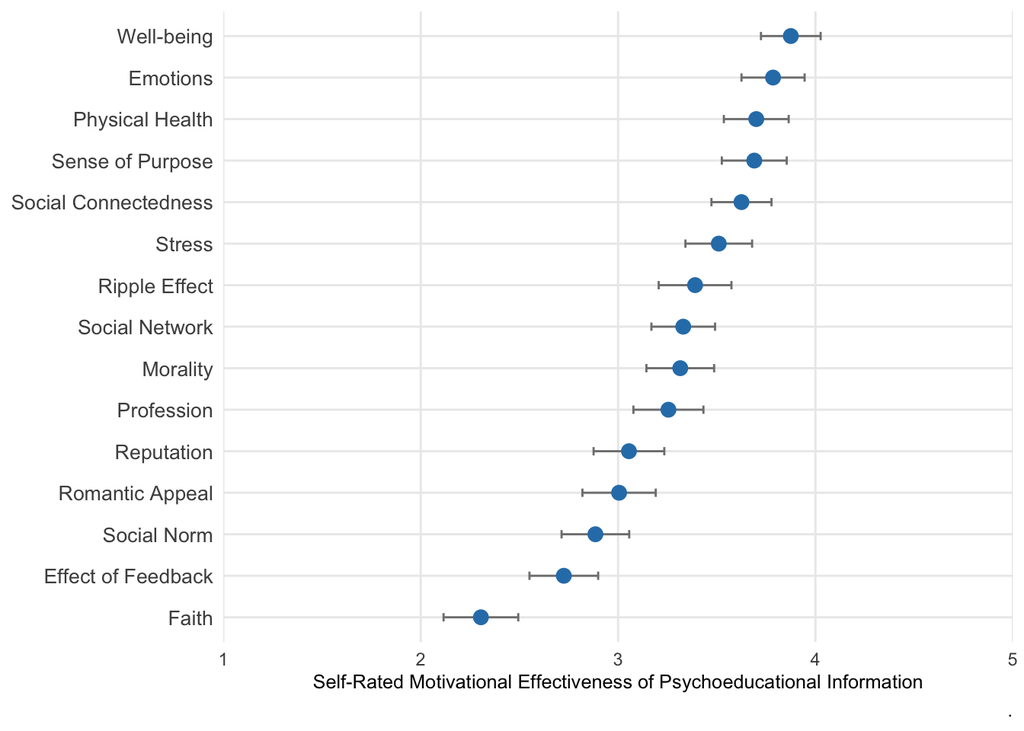

```r
#---------------------------------
# Create the dot graph with CI - Separated
#---------------------------------
# Creating a summary table of the effectiveness ratings' Mean, SD, N, and CI using the get_summary_with_CI function
motivator_summary_with_CI <- get_summary_with_CI(motivator)
# Drafting a dot plot of mean effectiveness ratings with CI
motivator_dot_plot <- ggplot(motivator_summary_with_CI, aes(x = variable_name, y = rating)) +
  # Draw the error bars
  geom_errorbar(aes(ymin = rating - ci, ymax = rating + ci),
                width = 0.2,
                color = "gray50") +
  # Draw the mean points
  geom_point(size = 3, color = "#2c7fb8") +

  # Set range
  # Remane the lables
  scale_y_continuous(breaks = c(1, 2, 3, 4, 5), expand = expansion(mult = c(0, 0))) +

  # Rename variables
  scale_x_discrete(
    labels = c(
      "Mot_wellbeing" = "Well-being",
      "Mot_stress" = "Stress",
      "Mot_religion" = "Faith",
      "Mot_moral" = "Morality",
      "Mot_emotion" = "Emotions",
      "Mot_meaning" = "Sense of Purpose",
      "Mot_health" = "Physical Health",
      "Mot_reputation" = "Reputation",
      "Mot_connection" = "Social Connectedness",
      "Mot_better_friends" = "Social Network",
      "Mot_job" = "Profession",
      "Mot_contagion" = "Ripple Effect",
      "Mot_romantic" = "Romantic Appeal",
      "Mot_norm" = "Social Norm",
      "Pro_score_reaction" = "Effect of Feedback"
    )
  ) +

  # Flip coordinates for easier reading
  coord_flip(ylim = c(1, 5)) +
  theme_minimal() +
  theme(
    panel.grid.minor = element_blank(),
    axis.title.y = element_blank(),
    axis.title.x = element_text(size = 9.5),
    axis.text.y = element_text(size = 10),
    plot.title = element_text(face = "bold")
  ) +
  labs(y = "Self-Rated Motivational Effectiveness of Psychoeducational Information", caption = ".")

# Print plot
motivator_dot_plot
```

```r
# Save plot
ggsave(
  filename = "../Figures/Figure 3_Mean Ratings of the Motivational Effectiveness of Psychoeducational Information.png",
  plot = motivator_dot_plot,
  width = 6,
  height = 4,
  dpi = 300
)
```

## 5.4 Graphs - Combine & Export

Combine the plots of the interactions between time and prosociality on the prosociality change goal in the feedback condition, psychoed condition, and all conditions.

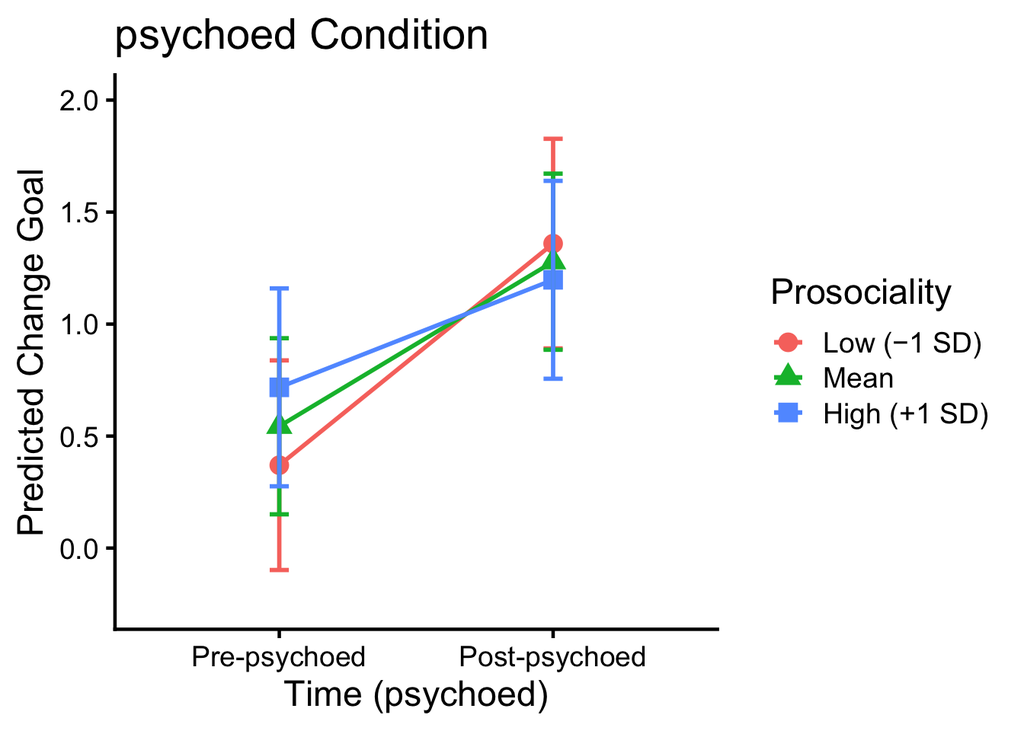

```r
# Make the range same across plots
psychoed_condition_plot <- psychoed_condition_plot + scale_y_continuous(limits = c(-0.25, 2))+ labs(title = "psychoed Condition")
feedback_condition_plot <- feedback_condition_plot + scale_y_continuous(limits = c(-0.25, 2))+ labs(title = "Feedback Condition")+ theme(axis.title.y = element_blank())
all_conditions_plot <- all_conditions_plot + scale_y_continuous(limits = c(-0.25, 2))+ labs(title = "All Conditions")+ theme(axis.title.y = element_blank())

psychoed_condition_plot
```

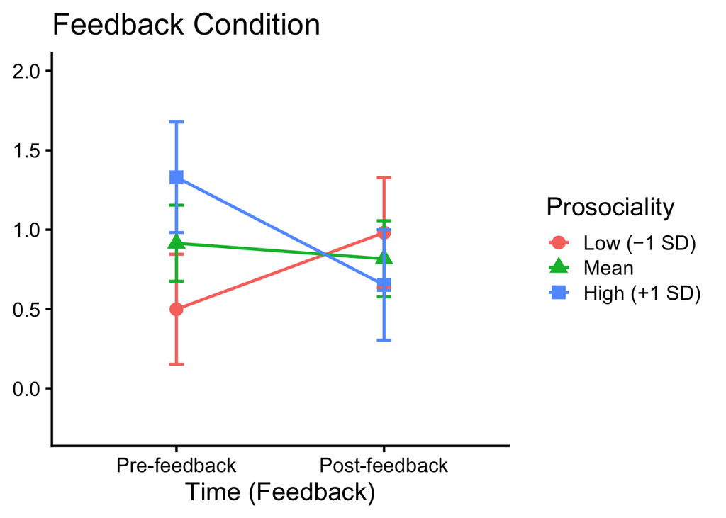

```r
feedback_condition_plot
```

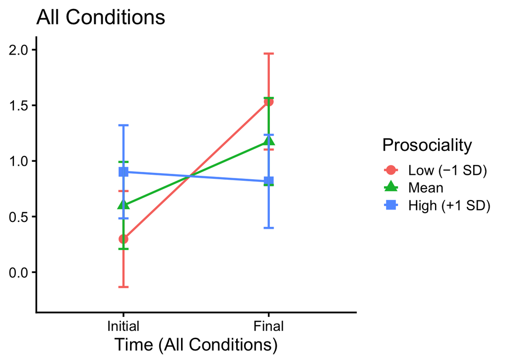

```r
all_conditions_plot
```

[figure not shown]

```r
# Combine plots side-by-side into one graph
combined_plot <- psychoed_condition_plot + feedback_condition_plot + all_conditions_plot +
  plot_layout(
    ncol = 3,
    guides = "collect",
    axis_titles = "collect",
    widths = c(1, 1, 1)
  ) +
  plot_annotation(
    tag_levels =
      "a")&
  theme(
    axis.title = element_text(size = 16),
    legend.position = "right",
    aspect.ratio = 1
  )

# Print graph
combined_plot
```

```r
# Save graph
ggsave(
  filename = "../Figures/Figure 2_The interactions between time and prosociality on the prosociality change goal.png",
  plot = combined_plot,
  width = 15,
  height = 5,
  dpi = 300
)
```